# Data Analysis for Deep Mutational Scanning - Analyses

Yuan Li

2023/10/04

# Data description

The source data for this analysis came from the two NextSeq runs - 8279 and 8332. The run parameters were as follows:

- P2, 600 cycle (2x 300 length)
- 20% PhiX
- submitting 5nM, 30 $\mu$L

I combined the two runs at the fastq level, rather than adding up the codoncounts after running each file with `dms_tools2`, because this will help maintain the sequences that had only been seen once in each run, but twice in the combined file. It turned out that my prediction worked less effectively than I thought, but it did maintain more sequences in most of the subamplicons, except for

- subamplicon 8, Rep0P0
- subamplicon 3, Rep1Pla
- subamplicon 5, Rep2Pla

I compared the two merging method. Combining at the fastq level gave me slightly more coverage for codon diversity and amino acid diversity. Therefore, I combined the two runs before running `dms_tools2`.

The merging was completed through bash and Greatlakes, with code

```bash
ls NextSeq_8279/fastqs_8279-WF/ | while read FILE; do
        gunzip -c NextSeq_8279/fastqs_8279-WF/"$FILE" NextSeq_8332/fastqs_8332-WF/"$FILE" | gzip > "fastqs_combined/${FILE#*/}"
    done
```

### Mutational coverage

- **Before filter**

| sample | codons created | total codons possible | codons created% | amino acids created | total amino acids possible | amino acids created% |
| --- | --- | --- | --- | --- | --- | --- |
| Rep1 | 22820 | 24647 | 92.6% | 15168 | 15897 | 95.4% |
| Rep2 | 21995 | 24647 | 89.2% | 14786 | 15897 | 93.0% |
| Rep3 | 20264 | 24647 | 82.2% | 14154 | 15897 | 89.0% |

- **After filter (count in plasmid > 10, freq > 6WTfreq)**

| sample | amino acids | amino acids% |
| --- | --- | --- |
| Rep1 | 11008 | 69.3% |
| Rep2 | 10565 | 66.5% |
| Rep3 | 10194 | 64.1% |
| present in all replicates | 7351 | 46.2% |
| present in at least one replicate | 13354 | 84.0% |

# Barcoded subamplicon sequencing analysis

The analysis was done using `dms2_batch_bcsubamp`, with bash code on Greatlakes

```bash
dms2_batch_bcsubamp --batchfile batchfile.csv --refseq PB1_reference_codon_orfonly --alignspecs 1,279,33,33 280,567,33,33 568,870,39,35 871,1200,34,30 1201,1509,33,33 1510,1776,33,30 1777,2058,30,33 2059,2274,35,41 --outdir ./results/codoncounts --summaryprefix summary --fastqdir ./fastqs_Combined/
```

### Diversity decrease throughout passages

We want to know how many codons or amino acids were lost after each step of the passage. In this sequencing run, we sequenced the plasmid, P0, P1, and P4. The diversity decrease was calculated using raw codon counts, filtered out the codons that I have not made, but didn’t corrected for the mutational hot spots, etc.

```r
counts_decrease <- tibble(
  sample = c("Rep1Pla","Rep1P0","Rep1P1","Rep1P4",
             "Rep2Pla","Rep2P0","Rep2P1","Rep2P4",
             "Rep3Pla","Rep3P0","Rep3P1","Rep3P4"),
  counts.remain = c(get_counts('Rep1Pla')[1],
                    get_counts('Rep1P0')[1],
                    get_counts('Rep1P1')[1],
                    get_counts('Rep1P4')[1],
                    get_counts('Rep2Pla')[1],
                    get_counts('Rep2P0')[1],
                    get_counts('Rep2P1')[1],
                    get_counts('Rep2P4')[1],
                    get_counts('Rep3Pla')[1],
                    get_counts('Rep3P0')[1],
                    get_counts('Rep3P1')[1],
                    get_counts('Rep3P4')[1]),
  aa.remain = c(get_counts('Rep1Pla')[2],
                get_counts('Rep1P0')[2],
                get_counts('Rep1P1')[2],
                get_counts('Rep1P4')[2],
                get_counts('Rep2Pla')[2],
                get_counts('Rep2P0')[2],
                get_counts('Rep2P1')[2],
                get_counts('Rep2P4')[2],
                get_counts('Rep3Pla')[2],
                get_counts('Rep3P0')[2],
                get_counts('Rep3P1')[2],
                get_counts('Rep3P4')[2])
)

counts_decrease$all.possible.codons <- 24647
counts_decrease$all.possible.aa <- 757*21
counts_decrease <- counts_decrease %>%
  mutate(codon.perc.remaining = counts.remain/all.possible.codons) %>%
  mutate(aa.perc.remaining = aa.remain/all.possible.aa) %>%
  mutate(replicate = substr(sample, 1, 4),
         passage = str_sub(sample, 5, -1))
```

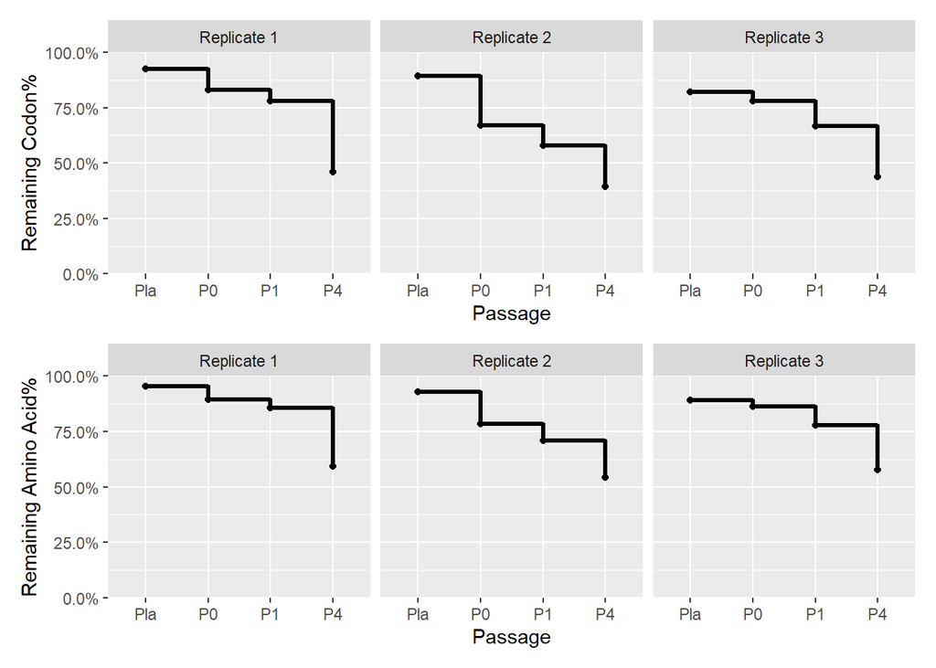

```r
facet_labs <- c("Replicate 1", "Replicate 2", "Replicate 3")
names(facet_labs) <- c("Rep1", "Rep2", "Rep3")

codon_decrease <- ggplot(counts_decrease, aes(x = fct_inorder(passage),
                                              y = codon.perc.remaining*100,
                                              group = replicate)) +
  geom_step(size = 1.1) +
  geom_point() +
  scale_y_continuous(labels = scales::label_percent(accuracy = .1, scale = 1),
                     limits = c(0, 100),
                     expand = expansion(0, 0)) +
  labs(x = "Passage", y = "Remaining Codon%") +
  facet_wrap(. ~ replicate, labeller = labeller(replicate = facet_labs))

aa_decrease <- ggplot(counts_decrease, aes(x = fct_inorder(passage),
                                           y = aa.perc.remaining*100,
                                           group = replicate)) +
  geom_step(size = 1.1) +
  geom_point() +
  scale_y_continuous(labels = scales::label_percent(accuracy = .1, scale = 1),
                     limits = c(0, 100),
                     expand = expansion(0, 0)) +
  labs(x = "Passage", y = "Remaining Amino Acid%") +
  facet_wrap(. ~ replicate, labeller = labeller(replicate = facet_labs))

codon_decrease / aa_decrease
```

# Amino acid preferences

Amino acid preferences were calculated using the method described in [Nicholas Wu et. al.](https://www.ncbi.nlm.nih.gov/pmc/articles/PMC9931530/pdf/nihms-1870513.pdf). The two filters on codoncounts are:

- filter input (mutant plasmid) count >= 10
- filter input frequency >= 6x WT frequency

In this method:

- Enrichment is defined as the ratio of frequency before and after passage;
- Fitness is defined as $\log_{10}{enrichment}$;
- Fitness is normalized to the average fitness of all silent mutations within corresponding individual subamplicon.

### Data read in

**Enrichment after P4**

```r
Rep1_enrichment <- compute_enrichment("Rep1Pla", "WTPla", "Rep1P4")
Rep2_enrichment <- compute_enrichment("Rep2Pla", "WTPla", "Rep2P4")
Rep3_enrichment <- compute_enrichment("Rep3Pla", "WTPla", "Rep3P4")

Rep1_fitness <- compute_fitness(Rep1_enrichment)
Rep2_fitness <- compute_fitness(Rep2_enrichment)
Rep3_fitness <- compute_fitness(Rep3_enrichment)

Rep1 <- subset(Rep1_fitness, select = c(site, amplicon, mutation, mutation.type, fitness))
Rep2 <- subset(Rep2_fitness, select = c(site, amplicon, mutation, mutation.type, fitness))
Rep3 <- subset(Rep3_fitness, select = c(site, amplicon, mutation, mutation.type, fitness))
```

`fitness_cor` calculates only for mutations present in all three replicates.

```r
fitness_cor <- Rep1 %>%
  inner_join(Rep2, by = c("site", "amplicon", "mutation", "mutation.type"),
             suffix = c(".Rep1", ".Rep2")) %>%
  inner_join(Rep3, by = c("site", "amplicon", "mutation", "mutation.type")) %>%
  rename("fitness.Rep3" = fitness)
```

`fitness_cor_full` accounts for mutations present in at least one replicate.

```r
fitness_cor_full <- Rep1 %>%
  full_join(Rep2, by = c("site", "amplicon", "mutation", "mutation.type"),
            suffix = c(".Rep1", ".Rep2")) %>%
  full_join(Rep3, by = c("site", "amplicon", "mutation", "mutation.type")) %>%
  rename("fitness.Rep3" = fitness)
```

### Fitness correlation

Fitness correlation measures how similar the fitness of each variant were in three replicates. Below shows the comparison between replicates, enrichment calculated with P4 (as post-passage), and plasmid (as pre-passage):

```r
LowerLimitRange <- function(data, mapping, ...) {
  ggplot(data = data, mapping = mapping, ...) +
    geom_point(...) +
    scale_y_continuous(limits = c(-4, 2), breaks = -4:2) +
    scale_x_continuous(limits = c(-4, 2), breaks = -4:2)
}
```

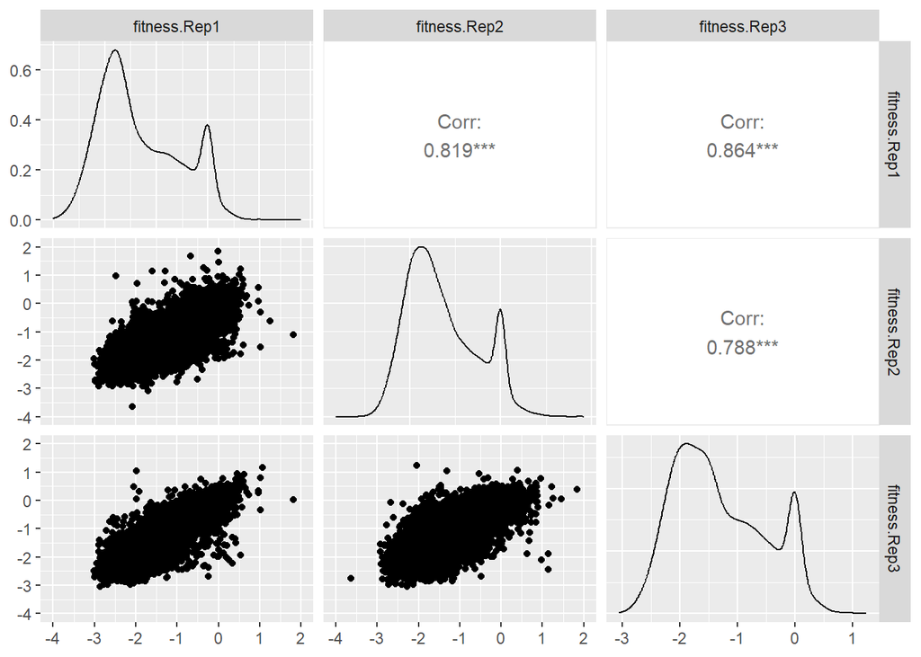

```r
fit_cor_ggpairs <- fitness_cor_full %>%
  ungroup() %>%
  select(fitness.Rep1, fitness.Rep2, fitness.Rep3)

ggpairs(fit_cor_ggpairs, lower = list(continuous = LowerLimitRange))
```

### Most mutations are detrimental, which ones are beneficial?

I want to be more stringent when calling a mutation beneficial. Therefore, 1) I used the mutations that were measured by at least two replicates; 2) I calculated the mean and s.d. for silent mutations, then calculated the z-score of all mutations using the mean and s.d. of silent mutations. Higher z-score means more beneficial.

```r
benemut <- fitness_cor_full %>%
  ungroup() %>%
  rowwise() %>%
  mutate(avg.fitness = mean(c(fitness.Rep1, fitness.Rep2, fitness.Rep3), na.rm = T))

benemut_silent_mean <- mean(filter(benemut, mutation.type == "silent")$avg.fitness)
benemut_silent_sd <- sd(filter(benemut, mutation.type == "silent")$avg.fitness)

benemut2 <- benemut[rowSums(is.na(benemut[5:7])) < 2, ]

benemut2 <- benemut2 %>%
  mutate(zscore = (avg.fitness - benemut_silent_mean)/benemut_silent_sd) %>%
  filter(mutation.type == "nonsense" | mutation.type =="missense")
```

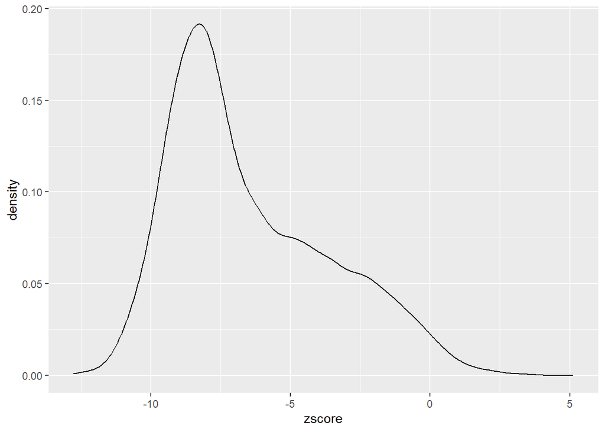

```r
ggplot(benemut2, aes(zscore)) +
  geom_density()
```

Which mutations are the most beneficial ones, and how beneficial are they exactly?

```r
benemut_table <- benemut2[order(benemut2$zscore, decreasing = T),] %>%
  select(site, amplicon, mutation, mutation.type, zscore) %>%
  filter(zscore >= 2)

print.data.frame(benemut_table)
```

```
##    site amplicon  mutation mutation.type   zscore
## 1   108        2 Leu108Tyr      missense 5.126652
## 2   647        7 Pro647Asn      missense 3.608524
## 3   577        6 Lys577Gln      missense 3.535065
## 4   255        3 Val255Ser      missense 3.490547
## 5   744        8 Met744Ala      missense 3.443046
## 6   116        2 Gln116Met      missense 3.409729
## 7   691        8 Lys691Arg      missense 3.162489
## 8   255        3 Val255Ala      missense 3.021593
## 9   679        7 Gln679Asn      missense 2.979386
## 10  510        6 Pro510Ala      missense 2.890052
## 11  151        2 Arg151Leu      missense 2.793400
## 12  164        2 Ile164Leu      missense 2.747743
## 13  351        4 Leu351Arg      missense 2.513735
## 14  105        2 Thr105Arg      missense 2.454788
## 15  323        4 Thr323Met      missense 2.386425
## 16  108        2 Leu108Arg      missense 2.372813
## 17  701        8 Pro701Leu      missense 2.360081
## 18  116        2 Gln116Thr      missense 2.281114
## 19  116        2 Gln116Val      missense 2.247724
## 20  261        3 Ser261Phe      missense 2.241466
## 21  510        6 Pro510Gly      missense 2.233921
## 22  317        4 Met317Val      missense 2.209847
## 23  646        7 Met646Ala      missense 2.150846
## 24  674        7 Ile674Leu      missense 2.073289
## 25  578        6 Lys578Thr      missense 2.050551
## 26  255        3 Val255Thr      missense 2.050218
## 27  653        7 Lys653Arg      missense 2.047385
## 28  637        7 Ile637Val      missense 2.025235
## 29  654        7 Asn654Asp      missense 2.020037
```

```r
# write.csv(benemut_table, "~/Manuscript/Table 2.csv", row.names=FALSE)
```

- Leu108Tyr was enriched for more than 10 times in two replicates;
- No nonsense mutation showed up as beneficial, which is a good sanity check.

The figure below shows which sites have how many beneficial mutations:

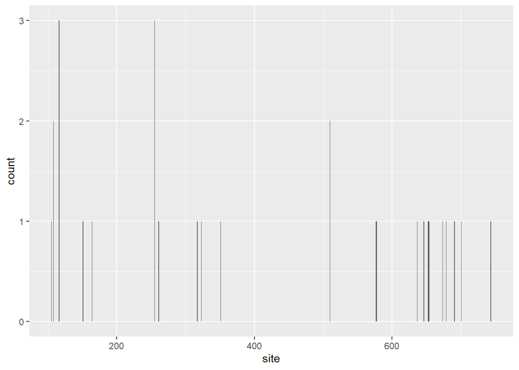

```r
# where are the beneficial mutations?
ggplot(filter(benemut2, zscore >= 2), aes(x = site)) +
  geom_bar()
```

### Mutation fitness distribution

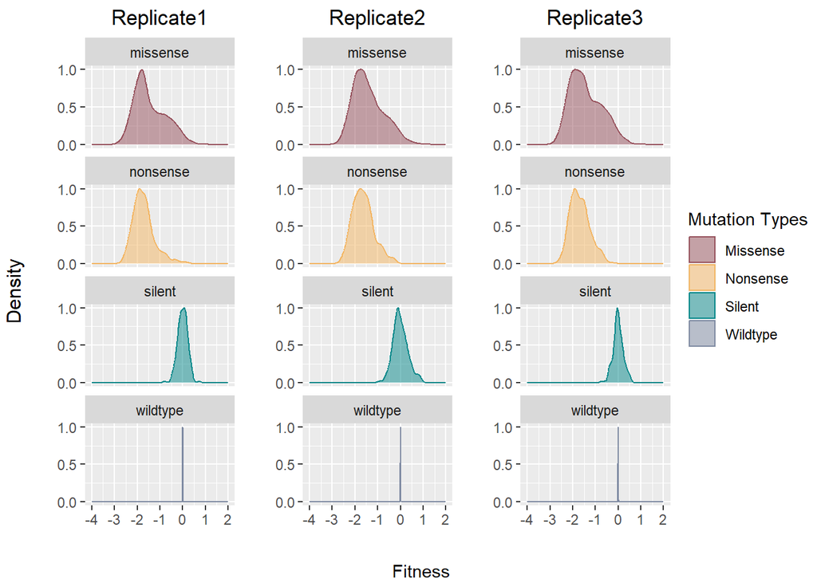

```r
fitness_distribution_plot <- function(fitness_file, title){
  fitness_plot <- ggplot(fitness_file, aes(x = fitness, y = after_stat(scaled),
                                           group = mutation.type,
                                           color = mutation.type,
                                           fill = mutation.type)) +
    geom_density(alpha = 0.5) +
    scale_color_manual(name = "Mutation Types",
        values=c(palette[8], palette[6], palette[4], palette[9]),
        breaks=c("missense", "nonsense", "silent", "wildtype"),
        labels=c("Missense", "Nonsense", "Silent", "Wildtype")) +
    scale_fill_manual(name = "Mutation Types",
        values=c(palette[8], palette[6], palette[4], palette[9]),
        breaks=c("missense", "nonsense", "silent", "wildtype"),
        labels=c("Missense", "Nonsense", "Silent", "Wildtype")) +
    labs(title = title, x = "", y = "") +
    scale_x_continuous(limits = c(-4, 2), breaks = -4:2) +
    scale_y_continuous(limits = c(0, 1), breaks = seq(0, 1, 0.5)) +
    theme(plot.title = element_text(hjust = 0.5)) +
    facet_wrap(~mutation.type, scales = "free_y", ncol = 1)

    return(fitness_plot)
  }

Rep1_fit_dis <- fitness_distribution_plot(Rep1, "Replicate1")
Rep2_fit_dis <- fitness_distribution_plot(Rep2, "Replicate2")
Rep3_fit_dis <- fitness_distribution_plot(Rep3, "Replicate3")

fitness_distribution <-
  ggarrange(Rep1_fit_dis, Rep2_fit_dis, Rep3_fit_dis, ncol=3, nrow=1,
          common.legend = TRUE, legend="right")

annotate_figure(fitness_distribution,
                bottom = text_grob("Fitness", size = fz_axis_title),
                left = text_grob("Density", rot = 90))
```

### Fitness heatmap

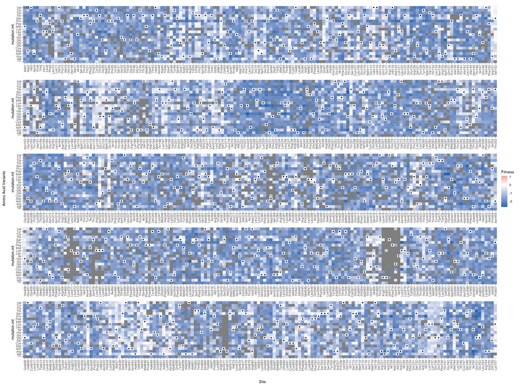

```r
fitness_cor_full$avg.fitness <- rowMeans(fitness_cor_full[,5:7], na.rm = TRUE)
fitness_cor_full$mutation.wt <- paste0(substr(gsub('\\d','', fitness_cor_full$mutation), 1, 3),
                                       gsub('\\D','', fitness_cor_full$mutation))
fitness_cor_full$mutation.mt <- substr(gsub('\\d','', fitness_cor_full$mutation), 4, 6)

fitness_cor_complete <- filter(fitness_cor_full, mutation.type != "silent") %>%
  complete(site, mutation.mt) %>%
  group_by(site) %>%
  fill(mutation.wt, .direction = "downup") %>%
  ungroup()

heatmap_plot <- function(avg_fitness_file){
  ggplot(avg_fitness_file, aes(x = fct_reorder(mutation.wt, site), y = mutation.mt)) +
    geom_tile(aes(fill = avg.fitness)) +
    labs(fill = "Fitness") +
    theme(axis.title.x = element_blank()) +
    theme(axis.text.x = element_text(angle = 90, vjust = 0.5, hjust=1)) +
    # theme(legend.position = "none") +
    scale_fill_gradient2(
      low = '#2166ac', mid = 'white', high = '#b2182b',
      midpoint = 0, na.value = "grey50", guide = 'colorbar', aesthetics = 'fill') +
    geom_point(data = filter(avg_fitness_file, mutation.type == "wildtype"))
}

htmp1 <- heatmap_plot(filter(fitness_cor_complete, site <= 152))
htmp2 <- heatmap_plot(filter(fitness_cor_complete, site >= 153 & site < 304))
htmp3 <- heatmap_plot(filter(fitness_cor_complete, site >= 304 & site < 456))
htmp4 <- heatmap_plot(filter(fitness_cor_complete, site >= 456 & site < 608))
htmp5 <- heatmap_plot(filter(fitness_cor_complete, site >= 608 & site <= 757))

p_axis <- ggplot() + labs(x = "Site", y = "Amino Acid Variants")
x_axis <- get_plot_component(p_axis, "xlab-b")
y_axis <- get_plot_component(p_axis, "ylab-l")

layout = "
CA
#B
"

ggarrange(htmp1, htmp2, htmp3, htmp4, htmp5, ncol=1, nrow=5,
          common.legend = TRUE, legend="right") + labs(x = NULL, y = NULL) +
  x_axis +
  y_axis +
  plot_layout(heights = c(40, 1), widths = c(1, 500), design = layout)
```

Generate the table for amino acid substitutions and fitness values:

```r
fitness_spreadsheet <- fitness_cor_complete %>%
  select(amplicon, site, mutation.wt, mutation.mt, avg.fitness)
fitness_spreadsheet$mutation.wt <- substr(fitness_spreadsheet$mutation.wt, 1, 3)
colnames(fitness_spreadsheet) <- c("amplicon","site","wildtype","substitution","fitness")

# write.csv(fitness_spreadsheet, "~/code/data/amino.acid.substitution.fitness.csv", row.names=FALSE)
```

# Comparing to existing data

```r
comparison <- read_csv(paste0(indir,"comparison.csv"))
comparison_subset <- subset(comparison, fitness.paper > 0)

#fitness.paper vs. fitness.dms
# after P0
# Spearman correlation calculated using whole dataset
rho_paper_vs_dms_p0 <- cor.test(x=comparison$fitness.dms.p0,
                                y=log10(comparison$fitness.paper),
                                method = 'spearman', exact=FALSE)
rho_paper_vs_dms_p0
```

```
##
##  Spearman's rank correlation rho
##
## data:  comparison$fitness.dms.p0 and log10(comparison$fitness.paper)
## S = 73.918, p-value = 0.001107
## alternative hypothesis: true rho is not equal to 0
## sample estimates:
##       rho
## 0.7969282
```

```r
# Pearson correlation calculated using viable mutations only
r_paper_vs_dms_p0 <- cor.test(x=comparison_subset$fitness.dms.p0,
                                y=log10(comparison_subset$fitness.paper),
                                method = 'pearson', exact=FALSE)
r_paper_vs_dms_p0
```

```
##
##  Pearson's product-moment correlation
##
## data:  comparison_subset$fitness.dms.p0 and log10(comparison_subset$fitness.paper)
## t = 3.4051, df = 6, p-value = 0.01441
## alternative hypothesis: true correlation is not equal to 0
## 95 percent confidence interval:
##  0.2502728 0.9646405
## sample estimates:
##       cor
## 0.8117799
```

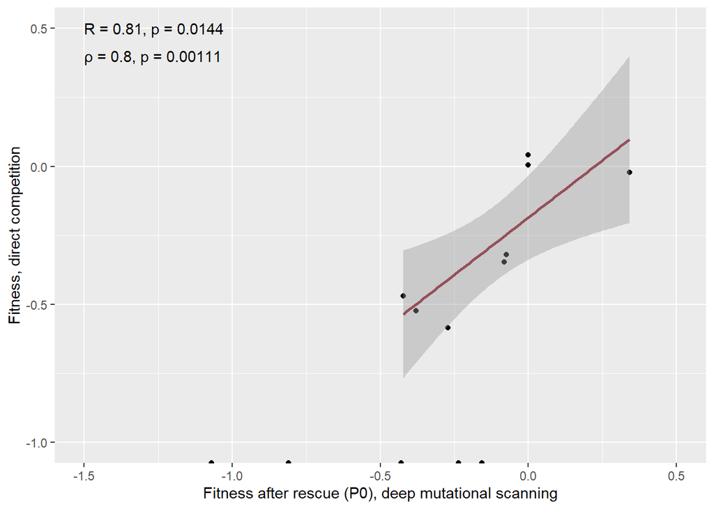

```r
ggplot(comparison, aes(x = fitness.dms.p0, y = log10(fitness.paper))) +
  geom_point() +
  geom_smooth(data=subset(comparison, fitness.paper > 0), formula = y ~ x,
              method = "lm", color = palette[8]) +
  annotate("text", x=-1.5, y=0.5, hjust = 0,
           label = paste0("R = ", signif(r_paper_vs_dms_p0$estimate, digits = 2), ", ",
                          "p = ", signif(r_paper_vs_dms_p0$p.value, digits = 3))) +
  annotate("text", x=-1.5, y=0.4, hjust = 0,
           label = paste0("\u03c1 = ", signif(rho_paper_vs_dms_p0$estimate, digits = 2), ", ",
                         "p = ", signif(rho_paper_vs_dms_p0$p.value, digits = 3))) +
  scale_x_continuous(limits = c(-1.5, 0.5), breaks = seq(-1.5, 0.5, by=0.5)) +
  scale_y_continuous(limits = c(-1, 0.5), breaks = seq(-1, 0.5, by=0.5)) +
  labs(x ="Fitness after rescue (P0), deep mutational scanning",
       y = "Fitness, direct competition")
```

```r
# after P1
# Spearman correlation calculated using whole dataset
rho_paper_vs_dms_p1 <- cor.test(x=comparison$fitness.dms.p1,
                                y=log10(comparison$fitness.paper),
                                method = 'spearman', exact=FALSE)
rho_paper_vs_dms_p1
```

```
##
##  Spearman's rank correlation rho
##
## data:  comparison$fitness.dms.p1 and log10(comparison$fitness.paper)
## S = 113.01, p-value = 0.009116
## alternative hypothesis: true rho is not equal to 0
## sample estimates:
##       rho
## 0.6895407
```

```r
# Pearson correlation calculated using viable mutations only
r_paper_vs_dms_p1 <- cor.test(x=comparison_subset$fitness.dms.p1,
                                y=log10(comparison_subset$fitness.paper),
                                method = 'pearson', exact=FALSE)
r_paper_vs_dms_p1
```

```
##
##  Pearson's product-moment correlation
##
## data:  comparison_subset$fitness.dms.p1 and log10(comparison_subset$fitness.paper)
## t = 8.4724, df = 6, p-value = 0.0001478
## alternative hypothesis: true correlation is not equal to 0
## 95 percent confidence interval:
##  0.7923930 0.9930712
## sample estimates:
##       cor
## 0.9606566
```

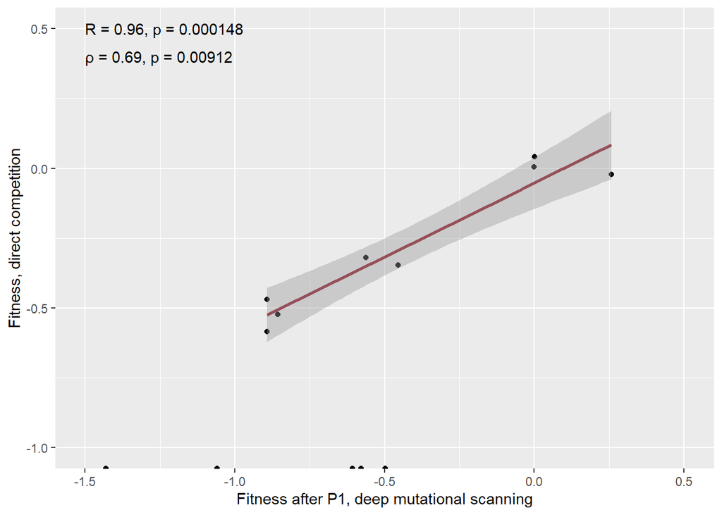

```r
ggplot(comparison, aes(x = fitness.dms.p1, y = log10(fitness.paper))) +
  geom_point() +
  geom_smooth(data=subset(comparison, fitness.paper > 0), formula = y ~ x,
              method = "lm", color = palette[8]) +
  annotate("text", x=-1.5, y=0.5, hjust = 0,
           label = paste0("R = ", signif(r_paper_vs_dms_p1$estimate, digits = 2), ", ",
                          "p = ", signif(r_paper_vs_dms_p1$p.value, digits = 3))) +
  annotate("text", x=-1.5, y=0.4, hjust = 0,
           label = paste0("\u03c1 = ", signif(rho_paper_vs_dms_p1$estimate, digits = 2), ", ",
                         "p = ", signif(rho_paper_vs_dms_p1$p.value, digits = 3))) +
  scale_x_continuous(limits = c(-1.5, 0.5), breaks = seq(-1.5, 0.5, by=0.5)) +
  scale_y_continuous(limits = c(-1, 0.5), breaks = seq(-1, 0.5, by=0.5)) +
  labs(x ="Fitness after P1, deep mutational scanning",
       y = "Fitness, direct competition")
```

```r
# after P4
# Spearman correlation calculated using whole dataset
rho_paper_vs_dms_p4 <- cor.test(x=comparison$fitness.dms.p4,
                                y=log10(comparison$fitness.paper),
                                method = 'spearman', exact=FALSE)
rho_paper_vs_dms_p4
```

```
##
##  Spearman's rank correlation rho
##
## data:  comparison$fitness.dms.p4 and log10(comparison$fitness.paper)
## S = 137.69, p-value = 0.0233
## alternative hypothesis: true rho is not equal to 0
## sample estimates:
##      rho
## 0.621717
```

```r
# Pearson correlation calculated using viable mutations only
r_paper_vs_dms_p4 <- cor.test(x=comparison_subset$fitness.dms.p4,
                                y=log10(comparison_subset$fitness.paper),
                                method = 'pearson', exact=FALSE)
r_paper_vs_dms_p4
```

```
##
##  Pearson's product-moment correlation
##
## data:  comparison_subset$fitness.dms.p4 and log10(comparison_subset$fitness.paper)
## t = 10.768, df = 6, p-value = 3.793e-05
## alternative hypothesis: true correlation is not equal to 0
## 95 percent confidence interval:
##  0.8642761 0.9956393
## sample estimates:
##       cor
## 0.9750888
```

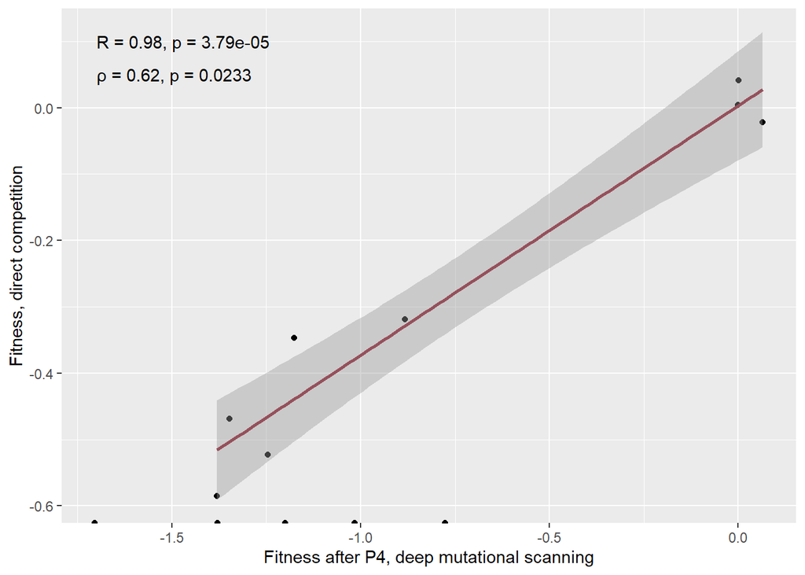

```r
ggplot(comparison, aes(x = fitness.dms.p4, y = log10(fitness.paper))) +
  geom_point() +
  geom_smooth(data=subset(comparison, fitness.paper > 0), formula = y ~ x,
              method = "lm", color = palette[8]) +
  annotate("text", x=-1.7, y=0.1, hjust = 0,
           label = paste0("R = ", signif(r_paper_vs_dms_p4$estimate, digits = 2), ", ",
                          "p = ", signif(r_paper_vs_dms_p4$p.value, digits = 3))) +
  annotate("text", x=-1.7, y=0.05, hjust = 0,
           label = paste0("\u03c1 = ", signif(rho_paper_vs_dms_p4$estimate, digits = 2), ", ",
                         "p = ", signif(rho_paper_vs_dms_p4$p.value, digits = 3))) +
  labs(x ="Fitness after P4, deep mutational scanning",
       y = "Fitness, direct competition")
```

# Site entropy

Site entropy refers to the Shannon entropy of each site. It is calculated by $h_r = -\displaystyle\sum_{x} \pi_{r,x} \log\left(\pi_{r,x}\right)$, where $\pi_{r,x}$ is the rescaled fitness for an amino acid variant, $x$ at site $r$, and the log is the natural logarithm. Rescaled fitness sum to 1 for each site. Site entropy was computed by the following code:

```r
Rep1_nolog_fitness <- compute_nolog_fitness(Rep1_enrichment)
Rep2_nolog_fitness <- compute_nolog_fitness(Rep2_enrichment)
Rep3_nolog_fitness <- compute_nolog_fitness(Rep3_enrichment)

Rep1_nolog <- subset(Rep1_nolog_fitness, select = c(site, amplicon, mutation, mutation.type, fitness))
Rep2_nolog <- subset(Rep2_nolog_fitness, select = c(site, amplicon, mutation, mutation.type, fitness))
Rep3_nolog <- subset(Rep3_nolog_fitness, select = c(site, amplicon, mutation, mutation.type, fitness))

entropy_calculation <- Rep1_nolog %>%
  full_join(Rep2_nolog, by = c("site", "amplicon", "mutation", "mutation.type"),
            suffix = c(".Rep1", ".Rep2")) %>%
  full_join(Rep3_nolog, by = c("site", "amplicon", "mutation", "mutation.type")) %>%
  rename("fitness.Rep3" = fitness) %>%
  rowwise() %>%
  mutate(avg.nolog.fitness = mean(c_across(c(fitness.Rep1, fitness.Rep2,
                                             fitness.Rep3)), na.rm = TRUE)) %>%
  filter(mutation.type != "silent") %>%
  group_by(site) %>%
  #rescale to add up to 1
  mutate(nolog.fitness.rescaled = avg.nolog.fitness/sum(avg.nolog.fitness)) %>%
  mutate(entropy = -(sum(nolog.fitness.rescaled * log(nolog.fitness.rescaled))))

domain <- read_csv(paste0(indir, "pb1domains.csv"))

entropy <- unique(entropy_calculation[, c(1,10)]) %>%
  left_join(domain, by = "site")
```

## Sites with low amino acid variants

You will notice that, in the fitness heatmap, there are some sites having more “grey squares” than others. The missing data will be of interest when calculating site entropy, because an amino acid variant that has low fitness and under purifying selection and an amino acid variant that was not in the plasmid library to begin with will contribute similarly to entropy calculation. Among all sites with low entropy, I want to mark the ones with less than 50% of all amino acid variants present in the plasmid library.

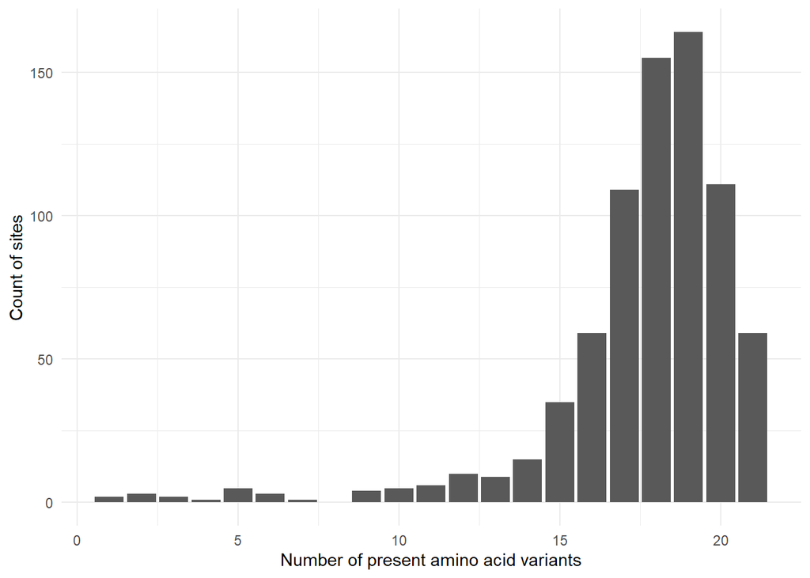

```r
aa_missing <- fitness_cor_complete %>%
  group_by(site) %>%
  summarize(sum(is.na(avg.fitness))) %>%
  mutate(aa.not.missing = 21-`sum(is.na(avg.fitness))`) %>%
  mutate(perc.not.missing = aa.not.missing/21)

ggplot(aa_missing, aes(x = aa.not.missing)) +
  geom_bar() +
  theme_minimal() +
  xlab("Number of present amino acid variants") +
  ylab("Count of sites")
```

```r
accurate_entropy <- filter(entropy, site %in% which(aa_missing$perc.not.missing >= 0.5))
```

## Entropy mapped on structure

For showing site entropy on actual PB1 structure, I chose PDB [7nhx](https://www.rcsb.org/structure/7NHX) as the model. This is a structure resolved recently for 1918 H1N1 influenza virus. In their [paper](https://www.nature.com/articles/s41467-021-27950-w), you can find related structures of PB1 in different status, which might come useful in the additional analyses.

The attributes of PDB were coded by [fixed characters for every ‘column’](https://www.cgl.ucsf.edu/chimera/docs/UsersGuide/tutorials/pdbintro.html#note1). Therefore, to add the entropy attribute, the easiest way is to replace an empty column with entropy data. Here, I replaced the b-factor (or temperature factor), with the following code:

```r
polymerase <- read.pdb(paste0(indir, "pdb/7nhx.pdb"), maxlines = -1, multi = FALSE, rm.insert = FALSE, rm.alt = FALSE, ATOM.only = FALSE, hex = FALSE, verbose = TRUE)

replace <- entropy %>%
  ungroup() %>%
  mutate(chain = "B") %>%
  mutate(resno = site) %>%
  select(chain, resno, entropy)

pb1_modified <- merge(polymerase$atom, replace, by = c("chain", "resno"), all.x = TRUE)
pb1_modified <- pb1_modified %>%
  mutate(b = case_when(!is.na(entropy) ~ formatC(entropy, digits = 2, format = "f"),
                       T ~ formatC(0, digits = 2, format = "f"))) %>%
  select(-entropy)

pb1_modified <- pb1_modified[order(pb1_modified$eleno), ]

polymerase$atom <- pb1_modified

# write.pdb(polymerase, file=paste0(outdir, "7nhx_modified.pdb"))
# manually added terminal lines between different chains; manually added the beginning text.
```

## Entropy vs. interaction

### Entropy vs. fitness

Site entropy captures the general mutability of a position. There is a hypothesis that if a certain site can tolerate any amino acid variation (high site entropy),the fitness of a mutation at that site should be closer to the wild type and in general higher. This also brings up the question **whether beneficial mutations would concentrate on more variable sites**.

```r
entropy_vs_fitness <- fitness_cor_full %>%
  ungroup() %>%
  select(site, avg.fitness) %>%
  inner_join(accurate_entropy, by = "site")

# Spearman's rank correlation coefficient
rho_fit <- cor.test(x=entropy_vs_fitness$entropy,
                y=entropy_vs_fitness$avg.fitness, method = 'spearman', exact=FALSE)
rho_fit
```

```
##
##  Spearman's rank correlation rho
##
## data:  entropy_vs_fitness$entropy and entropy_vs_fitness$avg.fitness
## S = 2.3517e+11, p-value < 2.2e-16
## alternative hypothesis: true rho is not equal to 0
## sample estimates:
##      rho
## 0.420868
```

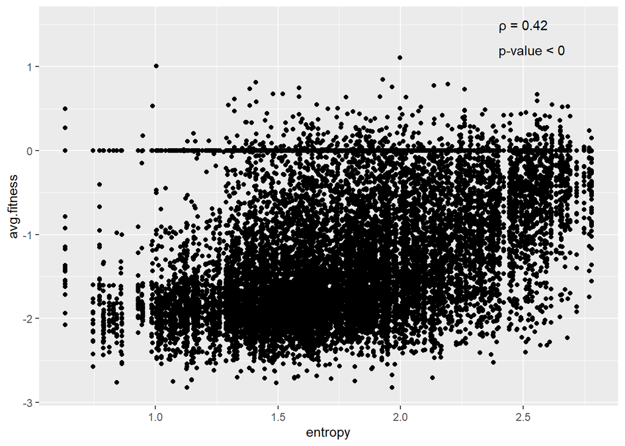

```r
ggplot(entropy_vs_fitness,
       aes(x = entropy, y = avg.fitness)) +
  geom_point() +
  annotate("text", x=2.4, y=1.5, hjust = 0,
           label = paste("\u03c1 =", signif(rho_fit$estimate, digits = 2))) +
  annotate("text", x=2.4, y=1.2, hjust = 0,
           label = paste("p-value <", rho_fit$p.value))
```

### Entropy vs. domains

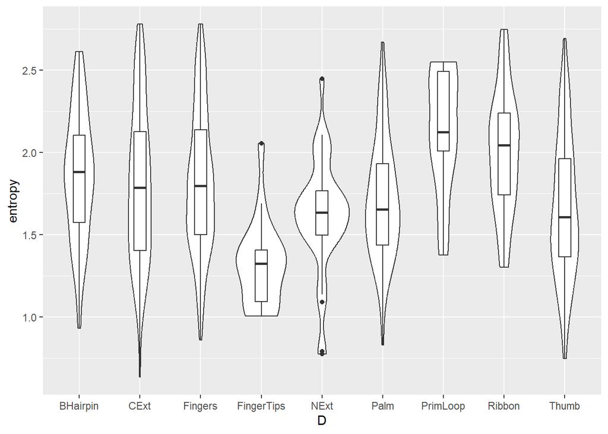

```r
ggplot(accurate_entropy, aes(x = D, y = entropy)) +
  geom_violin() +
  geom_boxplot(width=0.2)
```

```r
#ANOVA
domain_aov = aov(entropy~D, data = accurate_entropy)
summary(domain_aov)
```

```
##              Df Sum Sq Mean Sq F value   Pr(>F)
## D             8   11.3  1.4129   8.424 5.54e-11 ***
## Residuals   723  121.3  0.1677
## ---
## Signif. codes:
## 0 '***' 0.001 '**' 0.01 '*' 0.05 '.' 0.1 ' ' 1
```

```r
#expected entropy for each domain
domain_level = data.frame(D = unique(entropy$D))
data.frame(domain_level, expected.entropy = predict(domain_aov, domain_level))
```

```
##            D expected.entropy
## 1       NExt         1.618371
## 2    Fingers         1.814738
## 3     Ribbon         1.992944
## 4 FingerTips         1.318036
## 5       Palm         1.707543
## 6   BHairpin         1.853809
## 7      Thumb         1.658548
## 8   PrimLoop         2.125130
## 9       CExt         1.799785
```

Post Hoc Testing - which domains are different?

```r
with(accurate_entropy, pairwise.t.test(entropy, D, p.adj = "bonferroni"))
```

```
##
##  Pairwise comparisons using t tests with pooled SD
##
## data:  entropy and D
##
##            BHairpin CExt    Fingers FingerTips NExt
## CExt       1.00000  -       -       -          -
## Fingers    1.00000  1.00000 -       -          -
## FingerTips 0.00014  0.00023 3.3e-05 -          -
## NExt       0.44872  1.00000 0.33597 0.43528    -
## Palm       1.00000  1.00000 0.65663 0.00616    1.00000
## PrimLoop   0.75725  0.10191 0.09619 3.1e-07    0.00125
## Ribbon     1.00000  0.76817 0.71341 9.6e-07    0.00707
## Thumb      0.22132  0.39937 0.01262 0.03305    1.00000
##            Palm    PrimLoop Ribbon
## CExt       -       -        -
## Fingers    -       -        -
## FingerTips -       -        -
## NExt       -       -        -
## Palm       -       -        -
## PrimLoop   0.00309 -        -
## Ribbon     0.01373 1.00000  -
## Thumb      1.00000 0.00037  0.00092
##
## P value adjustment method: bonferroni
```

### Entropy vs. solvent accessibility

Solvent accessibility was calculated by [PISA](https://www.ebi.ac.uk/pdbe/pisa/pi_tips.html) in [CCP4](https://www.ccp4.ac.uk/). It is measured by rolling a water molecule probe of 1.4 in diameter over the surface of the protein and summing the surface area in contact with the probe for each residue on a protein of interest. I input the entire structure, PDB [7nhx](https://www.rcsb.org/structure/7NHX) and obtained the accessible surface area (ASA) for PB1 only.

```r
ASA <- read_table(paste0(indir, "ASA"), col_names = FALSE)

ASA <- ASA[,c("X3", "X4", "X6", "X7", "X8", "X9")]
colnames(ASA) <- c("amino.acid", "site", "ASA", "BSA", "dG", "dGi")

entropy_vs_ASA <- inner_join(accurate_entropy, ASA, by = "site")

# Spearman's rank correlation coefficient
rho_ASA <- cor.test(x=entropy_vs_ASA$ASA,
                y=entropy_vs_ASA$entropy, method = 'spearman', exact=FALSE)
rho_ASA
```

```
##
##  Spearman's rank correlation rho
##
## data:  entropy_vs_ASA$ASA and entropy_vs_ASA$entropy
## S = 42004191, p-value = 1.516e-14
## alternative hypothesis: true rho is not equal to 0
## sample estimates:
##       rho
## 0.2838061
```

```r
rho_ASA$p.value
```

```
## [1] 1.516358e-14
```

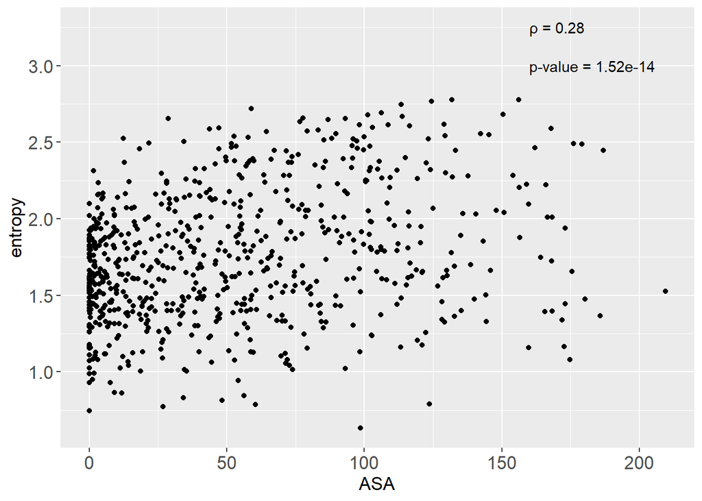

```r
ggplot(entropy_vs_ASA, aes(x = ASA, y = entropy)) +
  geom_point() +
  annotate("text", x=160, y=3.25, hjust = 0,
           label = paste("\u03c1 =", signif(rho_ASA$estimate, digits = 2))) +
  annotate("text", x=160, y=3, hjust = 0,
           label = paste("p-value =", signif(rho_ASA$p.value, digits = 3))) +
  theme(text = element_text(size=13),
        axis.text = element_text(size = 13))
```

Additionally, in the [pdb page for 7NHX](https://www.rcsb.org/sequence/7NHX#B), they marked “buried residues”. Using this annotation, I did a categorical analysis and compared the entropy difference between sites that are buried and sites that are exposed or partially exposed.

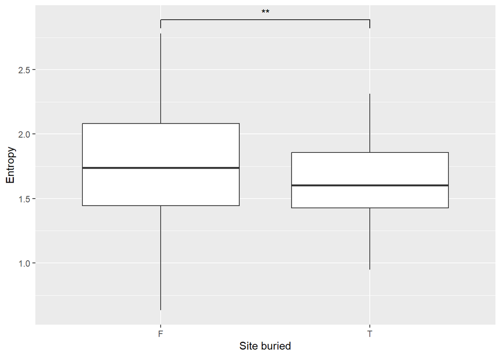

```r
buried <- read_csv(paste0(indir,"buried.sites.7nhx.csv"))
entropy_vs_buried <- inner_join(accurate_entropy, buried, by = "site") %>%
  filter(buried != "unknown")

ggplot(entropy_vs_buried, aes(x=buried, y=entropy)) +
  geom_boxplot() +
  labs(x="Site buried", y="Entropy") +
  geom_signif(comparisons = list(c("F", "T")), map_signif_level = TRUE,
              test = "wilcox.test")
```

```r
wilcox.test(entropy ~ buried, data = entropy_vs_buried)
```

```
##
##  Wilcoxon rank sum test with continuity correction
##
## data:  entropy by buried
## W = 38146, p-value = 0.002693
## alternative hypothesis: true location shift is not equal to 0
```

### Entropy vs. RMSF

**RMSD and RMSF**

RMSD stands for Root Mean Square Deviation. It is a numerical measurement representing the difference between two structures: in this case a *target structure* that changes overtime and a *reference structure* that is also the starting structure. RMSD is typically plotted vs. time.

RMSF stands for Root Mean Square Fluctuation. It measures similar things to RMSD but is a calculation of individual residue flexibility, or how much a particular residue moves (fluctuates) during a simulation. RMSF per residue is typically plotted vs. residue number, and can indicate structurally which amino acids in a protein contribute the most to a molecular motion.

```r
rmsf_avg <- read_excel(paste0(indir, "7nhx_md/rmsf_avg.xlsx"))
rmsf_calpha <- read_excel(paste0(indir, "7nhx_md/rmsf_calpha.xlsx"))
```

#### RMSF calculated by averaging all atoms at one residue

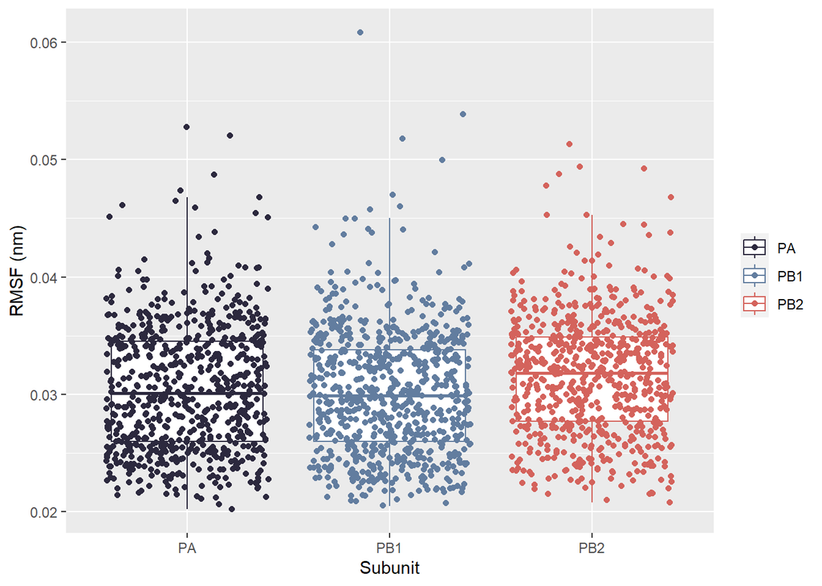

```r
rmsf_avg <- rmsf_avg %>%
  rename_with(~ c("residue", "RMSF"), 1:2) %>%
  mutate(subunit = rep(c("PA","PB1","PB2"),times=c(716,756,676)))

ggplot(rmsf_avg, aes(x=subunit, y=RMSF, color=subunit)) +
  geom_boxplot(outlier.shape=NA) +
  geom_jitter(shape=19)+
    scale_color_manual(name=NULL,
        values=c("#2C293E", "#627D9F", "#D4635C"),
        breaks=c("PA", "PB1", "PB2"),
        labels=c("PA", "PB1", "PB2")) +
    labs(x="Subunit", y="RMSF (nm)")
```

#### RMSF calculated by C-alpha of each residue

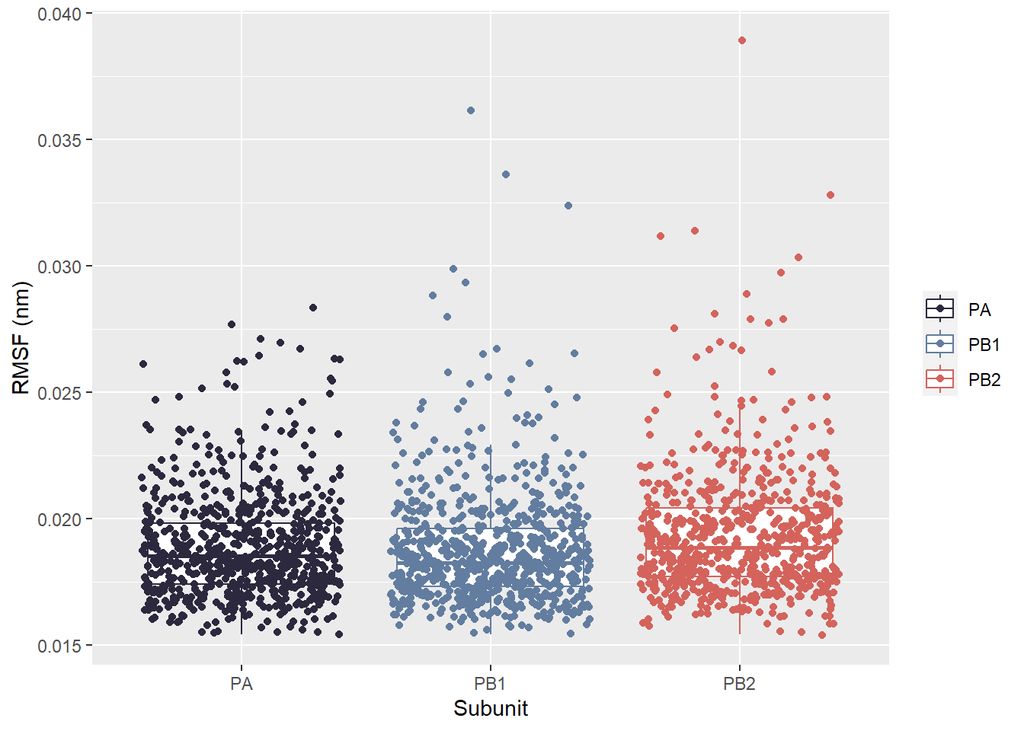

```r
rmsf_calpha <- rmsf_calpha %>%
  rename_with(~ c("residue", "CalphaNum", "RMSF"), 1:3) %>%
  mutate(subunit = rep(c("PA","PB1","PB2"),times=c(716,756,676))) %>%
  mutate(site = c(1:716, 1:756, 1:676))

ggplot(rmsf_calpha, aes(x=subunit, y=RMSF, color=subunit)) +
  geom_boxplot(outlier.shape=NA) +
  geom_jitter(shape=19)+
    scale_color_manual(name=NULL,
        values=c("#2C293E", "#627D9F", "#D4635C"),
        breaks=c("PA", "PB1", "PB2"),
        labels=c("PA", "PB1", "PB2")) +
    labs(x="Subunit", y="RMSF (nm)")
```

#### RMSF_avg vs. entropy

```r
rmsf_vs_ent_avg <- rmsf_avg %>%
  filter(subunit == "PB1") %>%
  inner_join(accurate_entropy, by = c("residue" = "site"))

# Spearman's rank correlation coefficient
rho_rmsf_avg <- cor.test(x=rmsf_vs_ent_avg$RMSF,
                y=rmsf_vs_ent_avg$entropy, method = 'spearman', exact=FALSE)
rho_rmsf_avg
```

```
##
##  Spearman's rank correlation rho
##
## data:  rmsf_vs_ent_avg$RMSF and rmsf_vs_ent_avg$entropy
## S = 51334489, p-value = 7.759e-09
## alternative hypothesis: true rho is not equal to 0
## sample estimates:
##       rho
## 0.2114864
```

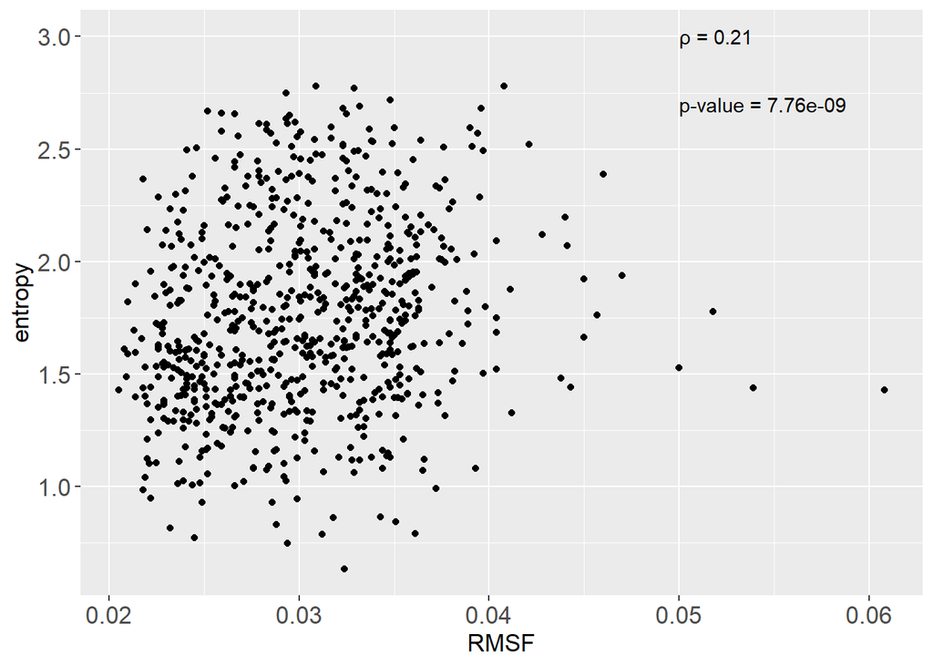

```r
ggplot(rmsf_vs_ent_avg, aes(x=RMSF, y=entropy)) +
  geom_point() +
  annotate("text", x=0.05, y=3, hjust = 0,
           label = paste("\u03c1 =", signif(rho_rmsf_avg$estimate, digits = 2))) +
  annotate("text", x=0.05, y=2.7, hjust = 0,
           label = paste("p-value =", signif(rho_rmsf_avg$p.value, digits = 3))) +
  theme(text = element_text(size=13),
        axis.text = element_text(size = 13))
```

#### RMSF_calpha vs. entropy

```r
rmsf_vs_ent_calpha <- rmsf_calpha %>%
  filter(subunit == "PB1") %>%
  select(-residue) %>%
  inner_join(accurate_entropy, by = "site")

# Spearman's rank correlation coefficient
rho_rmsf_calpha <- cor.test(x=rmsf_vs_ent_calpha$RMSF,
                y=rmsf_vs_ent_calpha$entropy, method = 'spearman', exact=FALSE)
rho_rmsf_calpha
```

```
##
##  Spearman's rank correlation rho
##
## data:  rmsf_vs_ent_calpha$RMSF and rmsf_vs_ent_calpha$entropy
## S = 61115025, p-value = 0.09795
## alternative hypothesis: true rho is not equal to 0
## sample estimates:
##        rho
## 0.06125437
```

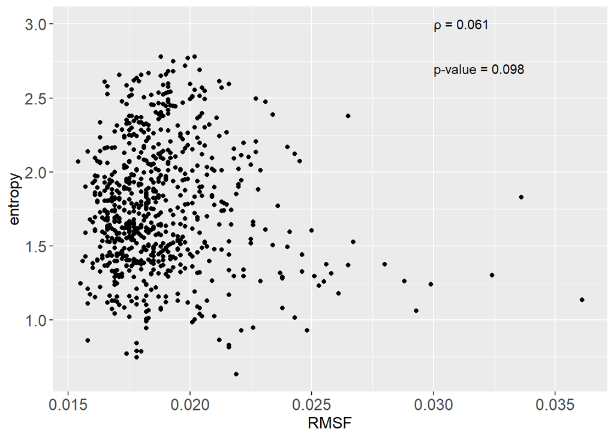

```r
ggplot(rmsf_vs_ent_calpha, aes(x=RMSF, y=entropy)) +
  geom_point() +
  annotate("text", x=0.03, y=3, hjust = 0,
           label = paste("\u03c1 =", signif(rho_rmsf_calpha$estimate, digits = 2))) +
  annotate("text", x=0.03, y=2.7, hjust = 0,
           label = paste("p-value =", signif(rho_rmsf_calpha$p.value, digits = 3))) +
  theme(text = element_text(size=13),
        axis.text = element_text(size = 13))
```

### Entropy and different stages of transcription

- Apoenzyme: 5d9a
- Template binding 1: 4wsb, 7nhx
- Template binding 2: 6t0n
- Cap-snatching: 5m3h
- Pre-initiation: 6rr7
- Mixed pre-initiation: 6qcw
- Mixed pre-catalysis: 6qcv
- Mixed post-incorporation: 6qcx, 6t0v
- Elongation: 6szv
- Termination: 6szu

There are three types of RNA binding to the polymerase: 3’vRNA, 5’vRNA, and mRNA (capped). I’ll discuss the interaction with them separately.

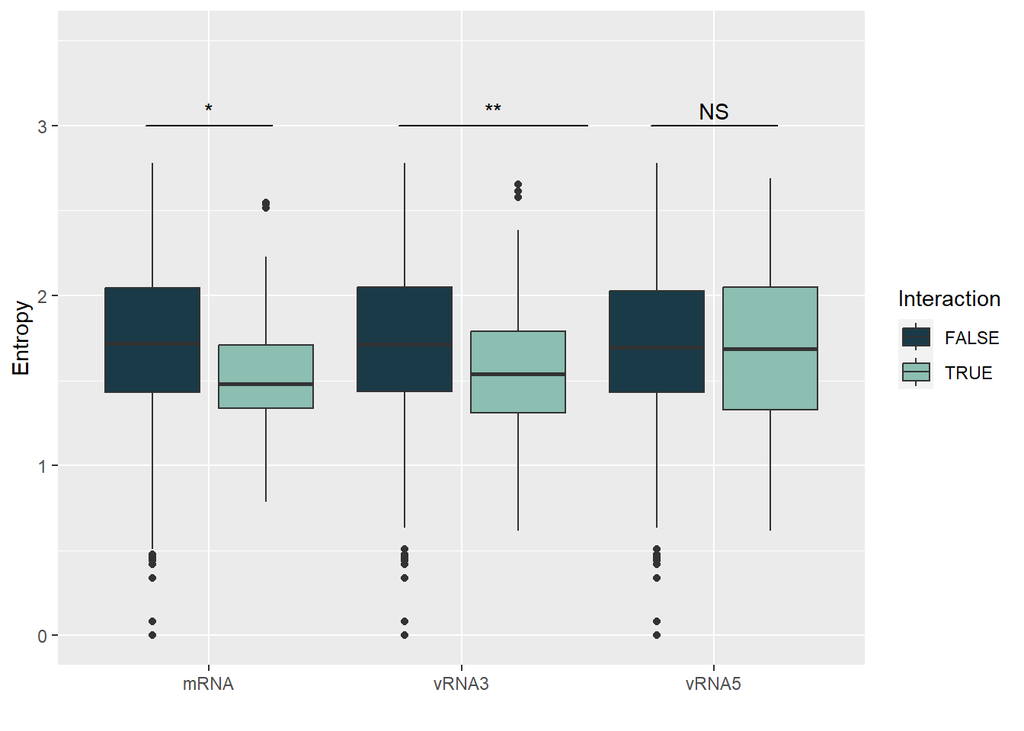

```r
trans_int <- read.csv(paste0(indir, "transcription.interaction.csv")) %>%
  rename_with(~ 'PDB', 1)

vRNA3 <- sort(unique(filter(trans_int, RNA.type == "3'vRNA")$PB1.residues))
vRNA5 <- sort(unique(filter(trans_int, RNA.type == "5'vRNA")$PB1.residues))
mRNA <- sort(unique(filter(trans_int, RNA.type == "capped mRNA")$PB1.residues))

RNA_int_ent <- entropy %>%
  mutate(vRNA3.int = ifelse(site %in% vRNA3, T, F),
         vRNA5.int = ifelse(site %in% vRNA5, T, F),
         mRNA.int = ifelse(site %in% mRNA, T, F))

RNA_int_ent_long <- RNA_int_ent %>%
  pivot_longer(
    cols = 4:6,
    names_to = "interaction",
    values_to = "T.or.F"
)

RNA_int_ent_long$interaction <- gsub('.{4}$', '', RNA_int_ent_long$interaction)

entropy_vs_int_plt <- ggplot(RNA_int_ent_long, aes(x = interaction, y = entropy)) +
  geom_boxplot(aes(fill = T.or.F), position = position_dodge(0.9)) +
  scale_fill_manual(values = c(palette[2], palette[3])) +
  labs(x="", y="Entropy", fill = "Interaction") +
  geom_signif(
    y_position = c(3, 3, 3), xmin = c(0.75, 1.75, 2.75), xmax = c(1.25, 2.5, 3.25),
    annotation = c("*", "**", "NS"), tip_length = 0) +
  ylim(0,3.5)

entropy_vs_int_plt
```

```r
# statistics using unpaired Two-Samples Wilcoxon Test (comparing the means of two independent groups (non-parametric))
wilcox.test(entropy ~ vRNA3.int, data = RNA_int_ent)
```

```
##
##  Wilcoxon rank sum test with continuity correction
##
## data:  entropy by vRNA3.int
## W = 23333, p-value = 0.00529
## alternative hypothesis: true location shift is not equal to 0
```

```r
wilcox.test(entropy ~ vRNA5.int, data = RNA_int_ent)
```

```
##
##  Wilcoxon rank sum test with continuity correction
##
## data:  entropy by vRNA5.int
## W = 25512, p-value = 0.4121
## alternative hypothesis: true location shift is not equal to 0
```

```r
wilcox.test(entropy ~ mRNA.int, data = RNA_int_ent)
```

```
##
##  Wilcoxon rank sum test with continuity correction
##
## data:  entropy by mRNA.int
## W = 16625, p-value = 0.01142
## alternative hypothesis: true location shift is not equal to 0
```

### What amino acids were allowed in interactions

**with 3’vRNA**

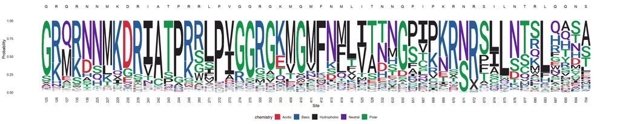

```r
vRNA3_logo <- get_logo_mat(vRNA3, entropy_calculation)
vRNA3_wt <- entropy_calculation %>%
  filter(site %in% vRNA3) %>%
  mutate(mutation.wt = substr(gsub('\\d','', mutation), 1, 3)) %>%
  group_by(site) %>%
  summarize(wt = aa321(toupper(unique(mutation.wt))))

ggplot() +
  geom_logo(vRNA3_logo, method = "prob", seq_type ='aa', stack_width = 0.90,
            namespace = "XACDEFGHIKLMNPQRSTVWY", col_scheme='chemistry') +
  scale_y_continuous(breaks=c(0.00,0.25,0.50,0.75, 1.00)) +
  annotate('text', x = 1:54, y = 1.2, label = vRNA3_wt$wt) +
  scale_x_continuous(breaks=1:54, labels = colnames(vRNA3_logo)) +
  xlab("Site") +
  theme_logo() +
  theme(axis.text.x=element_text(angle = 90, hjust = 0))
```

**with 5’vRNA**

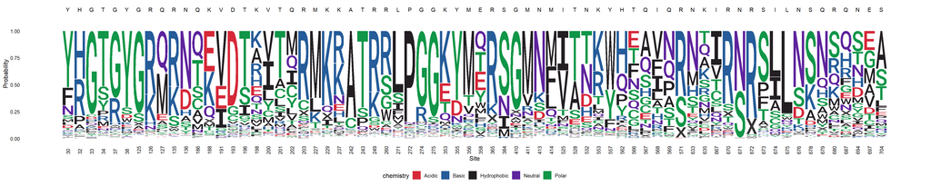

```r
vRNA5_logo <- get_logo_mat(vRNA5, entropy_calculation)
vRNA5_wt <- entropy_calculation %>%
  filter(site %in% vRNA5) %>%
  mutate(mutation.wt = substr(gsub('\\d','', mutation), 1, 3)) %>%
  group_by(site) %>%
  summarize(wt = aa321(toupper(unique(mutation.wt))))

ggplot() +
  geom_logo(vRNA5_logo, method = "prob", seq_type ='aa', stack_width = 0.90,
            namespace = "XACDEFGHIKLMNPQRSTVWY", col_scheme='chemistry') +
  scale_y_continuous(breaks=c(0.00,0.25,0.50,0.75, 1.00)) +
  annotate('text', x = 1:70, y = 1.2, label = vRNA5_wt$wt) +
  scale_x_continuous(breaks=1:70, labels = colnames(vRNA5_logo)) +
  xlab("Site") +
  theme_logo() +
  theme(axis.text.x=element_text(angle = 90, hjust = 0))
```

**with mRNA**

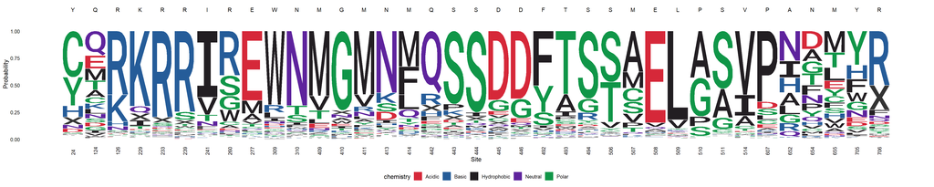

```r
mRNA_logo <- get_logo_mat(mRNA, entropy_calculation)
mRNA_wt <- entropy_calculation %>%
  filter(site %in% mRNA) %>%
  mutate(mutation.wt = substr(gsub('\\d','', mutation), 1, 3)) %>%
  group_by(site) %>%
  summarize(wt = aa321(toupper(unique(mutation.wt))))

ggplot() +
  geom_logo(mRNA_logo, method = "prob", seq_type ='aa', stack_width = 0.90,
            namespace = "XACDEFGHIKLMNPQRSTVWY", col_scheme='chemistry') +
  scale_y_continuous(breaks=c(0.00,0.25,0.50,0.75, 1.00)) +
  annotate('text', x = 1:37, y = 1.2, label = mRNA_wt$wt) +
  scale_x_continuous(breaks=1:37, labels = colnames(mRNA_logo)) +
  xlab("Site") +
  theme_logo() +
  theme(axis.text.x=element_text(angle = 90, hjust = 0))
```

**in motif c**

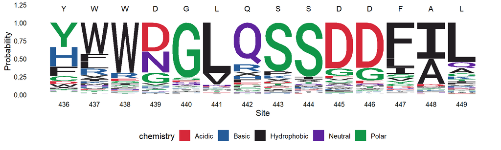

```r
motif_c_logo <- get_logo_mat(436:449, entropy_calculation)
# motif C containing active sites
# ggseqlogo(logomatrix, method = "prob", seq_type ='aa')
ggplot() +
  geom_logo(motif_c_logo, method = "prob", seq_type ='aa', stack_width = 0.90,
            namespace = "XACDEFGHIKLMNPQRSTVWY", col_scheme='chemistry') +
  annotate('text', x = 1:14, y = 1.2, label = c('Y', 'W', 'W', 'D', 'G', 'L', 'Q',
                                                'S', 'S', 'D', 'D', 'F', 'A', 'L')) +
  scale_x_continuous(breaks=1:14, labels = colnames(motif_c_logo)) +
  xlab("Site") +
  theme_logo()
```

# Comparing to naturally ocurring sequences

Finally, we want to compare the entropy obtained from deep mutational scanning to the diversity of naturally occurring IAV H1N1 PB1 sequences. I searched and downloaded sequences from [GISAID](https://gisaid.org/). Since we believe there was a sweeping evolutionary event during 2009 flu season, I divided the sequences into two subsets. Accroding to CDC’s [timeline](https://www.cdc.gov/flu/pandemic-resources/2009-pandemic-timeline.html), I divided the sequences into:

- pre09strains: collected before Apr.15, 2009
- post09strains: collected after Aug.11, 2010

Sequences were filtered with the following criteria before downloading:

- type A influenza
- H1N1
- human host
- required segment PB1 to be at least 757 amino-acid-long

When downloading the sequences:

- downloaded amino acid sequences (PB1) in fasta form
- sequence names were “Isolate_ID” (the unique names also show up in metadata)
- downloaded the corresponding metadata

I aligned them with [mafft](https://mafft.cbrc.jp/alignment/software/) on Greatlakes, using following code:

```bash
module load Bioinformatics
module load mafft

mafft --amino --anysymbol --6merpair --thread -1 --nomemsave --keeplength --addfragments AAsequencesCorrect/pre09AAnew.fasta PB1_reference_AA_orfonly > AAsequencesCorrect/pre09AAalignment_correct.fasta

mafft --amino --anysymbol --6merpair --thread -1 --nomemsave --keeplength --addfragments AAsequencesCorrect/post09AAnew.fasta PB1_reference_AA_orfonly > AAsequencesCorrect/post09AAalignment_correct.fasta
```

in which

- sequence type (protein / nucleotide) is automatically recognized based on the frequency of a, t, g, c, and u, unless the –amino or –nuc flag is given
- flag `--nomemsave` ensures the program to run efficiently
- flag `--addfragments` is a syntax for the sequences to align to a reference rather than each other
- and flag `--anysymbol` allows any characters to appear for a residue, which comes in handy for unified representation for ambiguous amino acids.

In *Report v1.0*, the Shannon diversity of naturally ocurring sequences were not weighted based on sampling, therefore the sequences from years (more recent years) that got sampled more frequently will influence more on the diversity of library. In this report, I employed and modified the code Sarah wrote for *MI* to adjust for the sampling bias.

**Metadata read in**

```r
pre09AAmetadata <- read_excel(paste0(indir, "naturalAAcorrect/pre09AAnewmetadata.xls")) %>%
  select(Isolate_Id, Isolate_Name, Passage_History, Host, Collection_Date) %>%
  mutate(group = substr(Collection_Date, 1, 4)) %>%
  filter(!str_detect(Passage_History, "egg|Egg|E[0-9]|AM|Am|E|e4|chicken") |
         is.na(Passage_History))

post09AAmetadata1 <- read_excel(paste0(indir, "naturalAAcorrect/post09AAnewmetadata1.xls")) %>%
  select(Isolate_Id, Isolate_Name, Passage_History, Host, Collection_Date)
post09AAmetadata2 <- read_excel(paste0(indir, "naturalAAcorrect/post09AAnewmetadata2.xls")) %>%
  select(Isolate_Id, Isolate_Name, Passage_History, Host, Collection_Date)

post09AAmetadata <- rbind(post09AAmetadata1, post09AAmetadata2) %>%
  mutate(group = substr(Collection_Date, 1, 4)) %>%
  filter(!str_detect(Passage_History, "egg|Egg|E[0-9]|AM|Am|E|e4|chicken") |
           is.na(Passage_History))
```

**Aligned fasta read in**

```r
aa_mat_pre09 <- readMSA(paste0(indir, "naturalAAcorrect/pre09AAalignment_correct.fasta"))
aa_mat_post09 <- readMSA(paste0(indir, "naturalAAcorrect/post09AAalignment_correct.fasta"))
```

There are 1656 sequences in `aa_mat_pre09` and 35980 sequences in `aa_mat_post09`. The first row is the provided reference sequence (WSN33 wildtype). Each column is a residue, therefore there are 758 columns in the matrices.

**Remove incomplete sequences**

```r
rm_rule <- function(input_matrix){
  sum(grepl('-', input_matrix)) > 0
}

aa_mat_pre09_complete <- aa_mat_pre09[ ,-758]
aa_mat_post09_complete <- aa_mat_post09[ ,-758]

# df[!apply(df, 1, rm_rule), ]
aa_mat_pre09_complete <- aa_mat_pre09_complete[!apply(aa_mat_pre09_complete, 1, rm_rule), ]
aa_mat_post09_complete <- aa_mat_post09_complete[!apply(aa_mat_post09_complete, 1, rm_rule), ]
```

**Find year of sequences with metadata**

```r
df_pre09 <- tibble(Isolate_Id = rownames(aa_mat_pre09_complete)) %>%
  inner_join(pre09AAmetadata, by = "Isolate_Id") %>%
  select(Isolate_Id, group)

df_post09 <- tibble(Isolate_Id = rownames(aa_mat_post09_complete)) %>%
  inner_join(post09AAmetadata, by = "Isolate_Id") %>%
  select(Isolate_Id, group)
```

**Calculate Shannon diversity for each residue**

```r
shannon_diversity_pre09 <- get_ent_all_sites(aa_mat_pre09_complete, df_pre09)
shannon_diversity_post09 <- get_ent_all_sites(aa_mat_post09_complete, df_post09)

nat_shannon <- tibble(site = c(1:757),
             pre09 = shannon_diversity_pre09,
             post09 = shannon_diversity_post09) %>%
  pivot_longer(-site, names_to = "year", values_to = "shannon.diversity")
```

```r
nat_shannon_wide <- tibble(site = c(1:757),
             pre09 = shannon_diversity_pre09,
             post09 = shannon_diversity_post09)

sum(nat_shannon_wide[2] == 0)
```

```
## [1] 505
```

```r
sum(nat_shannon_wide[3] == 0)
```

```
## [1] 1
```

**Plot Shannon diversity, compare between pre- and post-2009**

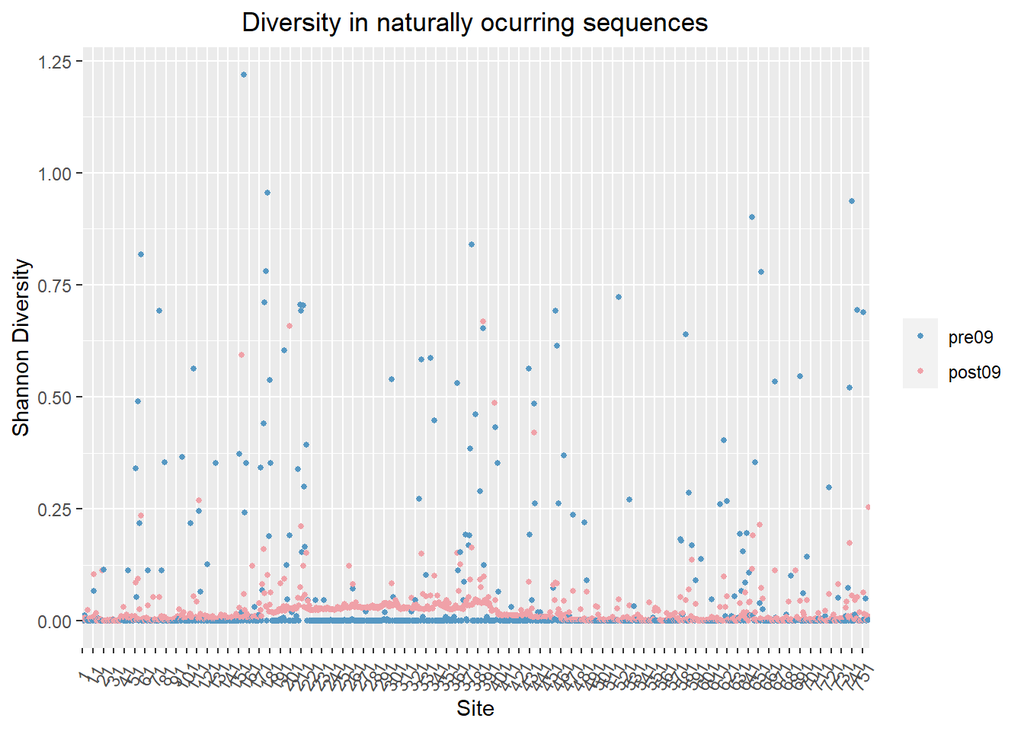

```r
ggplot(nat_shannon, aes(x=as.factor(site), y=shannon.diversity, color = year)) +
  geom_point(shape=19, size=1) +
  scale_color_manual(name=NULL,
        values=c("#5698c3", "#f0a1a8"),
        breaks=c("pre09", "post09"),
        labels=c("pre09", "post09")) +
  theme(axis.text.x = element_text(angle = 60, hjust = 0.5, vjust = 0.5),
        plot.title = element_text(hjust = 0.5),
        legend.position = "right") +
  scale_x_discrete(breaks = every_nth(n = 10)) +
  labs(x="Site", y="Shannon Diversity",
       title = "Diversity in naturally ocurring sequences")
```

**Compare entropy in naturally occurring sequences and DMS**

```r
natural_vs_dms <- tibble(site = c(1:757),
             pre09 = shannon_diversity_pre09,
             post09 = shannon_diversity_post09) %>%
  full_join(entropy[-758,c(1,2)], by = "site") %>%
  rename("dms" = entropy)

# pre09
rho_pre09 <- cor.test(x=natural_vs_dms$pre09,
                y=natural_vs_dms$dms, method = 'spearman', exact=FALSE)
rho_pre09
```

```
##
##  Spearman's rank correlation rho
##
## data:  natural_vs_dms$pre09 and natural_vs_dms$dms
## S = 43103543, p-value < 2.2e-16
## alternative hypothesis: true rho is not equal to 0
## sample estimates:
##       rho
## 0.4038201
```

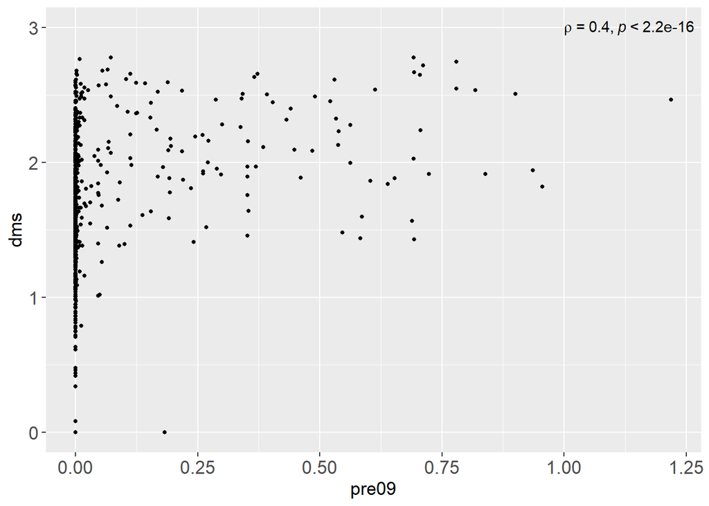

```r
ggplot(natural_vs_dms, aes(x=pre09, y=dms)) +
  geom_point(shape=19, size=1) +
  stat_cor(method = "spearman", cor.coef.name = "rho",
           label.x = 1, label.y = 3) +
  theme(text = element_text(size=13),
        axis.text = element_text(size = 13))
```

```r
# post09
rho_post09 <- cor.test(x=natural_vs_dms$post09,
                y=natural_vs_dms$dms, method = 'spearman', exact=FALSE)
rho_post09
```

```
##
##  Spearman's rank correlation rho
##
## data:  natural_vs_dms$post09 and natural_vs_dms$dms
## S = 49661909, p-value < 2.2e-16
## alternative hypothesis: true rho is not equal to 0
## sample estimates:
##       rho
## 0.3131091
```

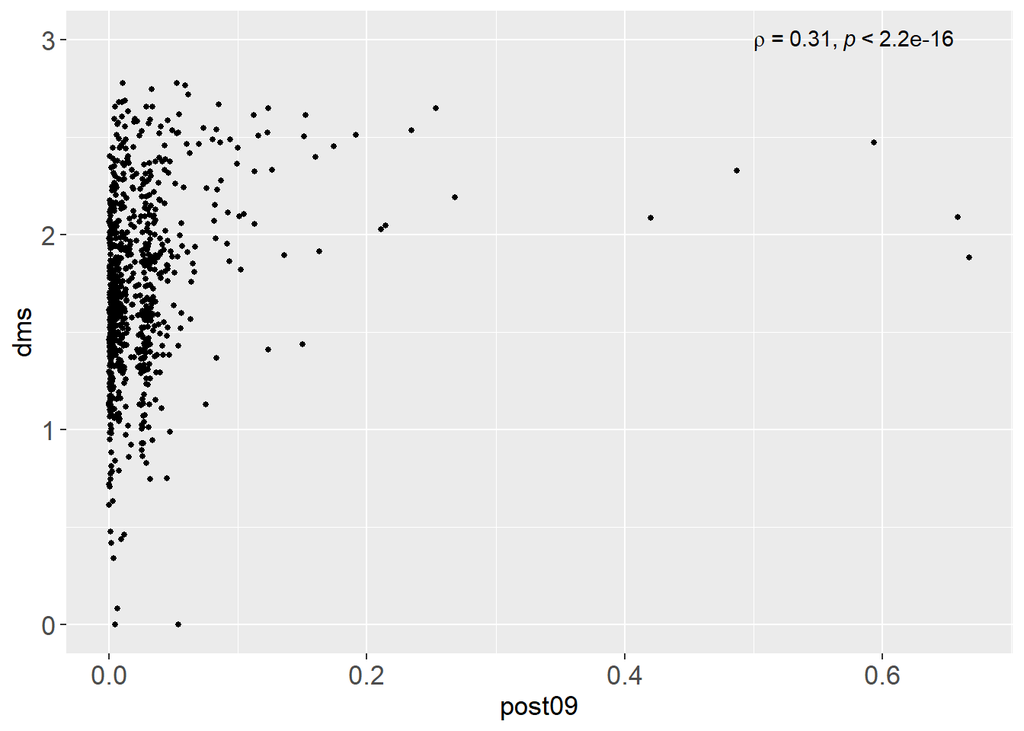

```r
ggplot(natural_vs_dms, aes(x=post09, y=dms)) +
  geom_point(shape=19, size=1) +
  stat_cor(method = "spearman", cor.coef.name = "rho",
           label.x = 0.5, label.y = 3) +
  theme(text = element_text(size=13),
        axis.text = element_text(size = 13))
```

# Accessibility of beneficial mutations

First, calculate the minimum nucleotide changes from one amino acid to another (including stop). There are $A_{21}^2 = 420$ changes possible. The following code makes such table.

```r
aa_comb <- combn(unique(codons$aa), 2)

min_diff_set <- data.frame()
for (i in 1:dim(aa_comb)[2]){
  str1 <- pull(filter(codons, aa == aa_comb[,i][1]), codon)
  str2 <- pull(filter(codons, aa == aa_comb[,i][2]), codon)

  min_codon_diff <- min(compare_str(str1,str2)$CodonDiff)

  vector <- c(aa_comb[,i][1], aa_comb[,i][2], min_codon_diff)
  min_diff_set <- rbind(min_diff_set, vector)
  colnames(min_diff_set) <- c("AA1", "AA2", "MinCodonDiff")
}

min_diff_set_rev <- tibble(min_diff_set$AA2, min_diff_set$AA1,
                           min_diff_set$MinCodonDiff)
colnames(min_diff_set_rev) <- c("AA1", "AA2", "MinCodonDiff")
min_codon_distance <- rbind(min_diff_set, min_diff_set_rev)
```

Then I examined the mutations with z-score greater than 2 on the beneficial side - how many nucleotide change the wild type needs to make to become the target amino acid. All beneficial mutations require 1 or 2 nucleotide changes.

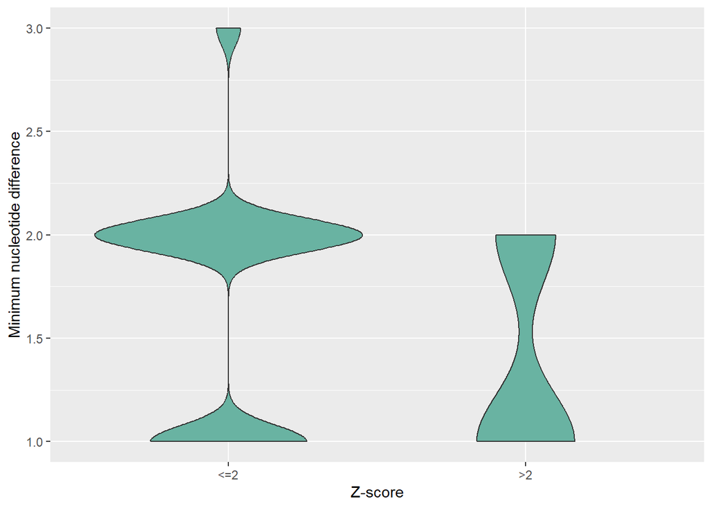

```r
benemut3 <- benemut2[order(benemut2$zscore, decreasing = T),] %>%
  select(site, amplicon, mutation, mutation.type, avg.fitness, zscore)

benemut3_codon_distance <- benemut3 %>%
  mutate(wt = substr(mutation, 1, 3)) %>%
  mutate(mt = str_sub(mutation, -3, -1)) %>%
  left_join(min_codon_distance, by = c("wt"="AA1", "mt"="AA2")) %>%
  select(site, amplicon, mutation, avg.fitness, zscore, MinCodonDiff) %>%
  mutate(bin = case_when(zscore > 2 ~ ">2",
                         T ~ "<=2"))

ggplot(benemut3_codon_distance, aes(x=fct_reorder(bin, as.integer(zscore)),
                                    y=as.numeric(MinCodonDiff))) +
  geom_violin(fill="#69b3a2") +
  # geom_dotplot(binaxis = "y", stackdir = "center", position = "stack",
  #              binwidth = 0.25, dotsize=0.05) +
  xlab("Z-score") +
  ylab("Minimum nucleotide difference")
```

```r
# Kolmogorov–Smirnov test: non-parametric, to test whether two samples follow the same distribution using using CDF.
ks.test(as.numeric(filter(benemut3_codon_distance, bin == ">2")$MinCodonDiff),
        as.numeric(filter(benemut3_codon_distance, bin == "<=2")$MinCodonDiff))$p.value
```

```
## [1] 0.027987
```

## Have beneficial mutations appeared in naturally occurring sequences?

Since there is a gap in pre- and post-09 groups. I will read in new data for this section. The new data is basically the entire natural PB1 records on GISAID up to 2023, without a gap. I also aligned the sequences to the wildtype WSN33 PB1 as described in the previous section. The full data set is under code/data/naturalAAall/alltimeH1N1AAalignment.fasta.

**Full set metadata read in**

```r
nat_metadata1 <- read_excel(paste0(indir, "naturalAAall/all.pre09metadata.xls")) %>%
  select(Isolate_Id, Isolate_Name, Passage_History, Host, Collection_Date)
nat_metadata2 <- read_excel(paste0(indir, "naturalAAall/all.09to18metadata.xls")) %>%
  select(Isolate_Id, Isolate_Name, Passage_History, Host, Collection_Date)
nat_metadata3 <- read_excel(paste0(indir, "naturalAAall/all.19to23metadata.xls")) %>%
  select(Isolate_Id, Isolate_Name, Passage_History, Host, Collection_Date)

nat_metadata <- rbind(nat_metadata1, nat_metadata2, nat_metadata3) %>%
  mutate(group = substr(Collection_Date, 1, 4)) %>%
  filter(!str_detect(Passage_History, "egg|Egg|E[0-9]|AM|Am|E|e4|chicken") |
           is.na(Passage_History))
```

**Full set aligned fasta read in**

```r
nat_aa_seq <- readMSA(paste0(indir, "naturalAAall/alltimeH1N1AAalignment.fasta"))
```

```r
nat_aa <- data.frame(Isolate_Id = row.names(nat_aa_seq), nat_aa_seq) %>%
  inner_join(nat_metadata, by = "Isolate_Id")

benemut4 <- benemut3 %>%
  filter(zscore >2) %>%
  mutate(wt = substr(mutation, 1, 3)) %>%
  mutate(mt = str_sub(mutation, -3, -1)) %>%
  left_join(min_codon_distance, by = c("wt"="AA1", "mt"="AA2")) %>%
  mutate(wt = aa321(toupper(wt)),
         mt = aa321(toupper(mt)))
```

### Site 108

```r
# beneficial mutations at that site
benemut4[which(benemut4$site == 108), ]$mt
```

```
## [1] "Y" "R"
```

```r
# naturally occurred mutations at that site
unique(nat_aa$X108)
```

```
##  [1] "L" "-" "I" "F" "H" "X" "R" "Q" "P" "V"
```

```r
# compare
benemut4[which(benemut4$site == 108), ]$mt %in% unique(nat_aa$X108)
```

```
## [1] FALSE  TRUE
```

```r
# if the beneficial mutation has appeared, when?
nat_aa[which(nat_aa$X108 == "R"), ] %>%
  select(colnames(nat_metadata))
```

```
##             Isolate_Id       Isolate_Name   Passage_History
## 8879    EPI_ISL_221267 A/Missouri/12/2016          Original
## 35336 EPI_ISL_17095762   A/Ceuta/355/2023 Clinical Specimen
##        Host Collection_Date group
## 8879  Human      2016-03-21  2016
## 35336 Human      2023-01-16  2023
```

```r
# how frequently did the mutation happen?
filter(nat_aa, group %in% c(2016,2023)) %>%
  group_by(group) %>%
  select(X108) %>%
  table()
```

```
##       X108
## group     -    F    I    L    R    X
##   2016    1    2    2 3588    1    0
##   2023   47    0    5 2947    1   18
```

In WSN33, the wildtype at site 108 is *L (Leu)*, but both *I (Ile)* and *L* existed at site 108 before 2009. From the data between 1995 and 2008, *I* might be the dominant amino acid. After 2009, *L* became the dominant amino acid. The minimum nucleotide changes for *L* and *I* to become *Y* are both 2. The minimum nucleotide changes for *L* and *I* to become *R* are both 1.

### Site 647

```r
# beneficial mutations at that site
benemut4[which(benemut4$site == 647), ]$mt
```

```
## [1] "N"
```

```r
# naturally occurred mutations at that site
unique(nat_aa$X647)
```

```
## [1] "P" "-" "Q" "X" "S" "T" "W" "L"
```

```r
# compare
benemut4[which(benemut4$site == 647), ]$mt %in% unique(nat_aa$X647)
```

```
## [1] FALSE
```

### Site 577

```r
# beneficial mutations at that site
benemut4[which(benemut4$site == 577), ]$mt
```

```
## [1] "Q"
```

```r
# naturally occurred mutations at that site
unique(nat_aa$X577)
```

```
##  [1] "K" "R" "-" "N" "Q" "E" "T" "M" "X" "S"
```

```r
# compare
benemut4[which(benemut4$site == 577), ]$mt %in% unique(nat_aa$X577)
```

```
## [1] TRUE
```

```r
# if the beneficial mutation has appeared, when?
nat_aa[which(nat_aa$X577 == "Q"), ] %>%
  select(colnames(nat_metadata))
```

```
##          Isolate_Id            Isolate_Name Passage_History
## 4529 EPI_ISL_122521 A/Singapore/GP4419/2009              C1
##       Host Collection_Date group
## 4529 Human      2009-11-23  2009
```

```r
# how frequently did the mutation happen?
filter(nat_aa, group == 2009) %>%
  select(X577) %>%
  table()
```

```
## .
##    -    K    N    Q    R
##    2 4766    4    1    6
```

### Site 255

```r
# beneficial mutations at that site
benemut4[which(benemut4$site == 255), ]$mt
```

```
## [1] "S" "A" "T"
```

```r
# naturally occurred mutations at that site
unique(nat_aa$X255)
```

```
## [1] "V" "-" "A" "X"
```

```r
# compare
benemut4[which(benemut4$site == 255), ]$mt %in% unique(nat_aa$X255)
```

```
## [1] FALSE  TRUE FALSE
```

```r
# if the beneficial mutation has appeared, when?
nat_aa[which(nat_aa$X255 == "A"), ] %>%
  select(colnames(nat_metadata))
```

```
##             Isolate_Id                Isolate_Name
## 2748     EPI_ISL_78803       A/Taipei/WR0194N/2009
## 3442     EPI_ISL_87579     A/Quito/WRAIR0617T/2009
## 19130 EPI_ISL_14749480        A/Viet nam/1492/2015
## 25875   EPI_ISL_414836 A/South Carolina/11221/2020
## 30602 EPI_ISL_14883643       A/Nepal/22FL2393/2022
## 30693 EPI_ISL_15260060       A/Nepal/22FL2393/2022
##       Passage_History  Host Collection_Date group
## 2748            MDCK2 Human      2009-09-01  2009
## 3442             <NA> Human      2009-10-07  2009
## 19130            <NA> Human      2015-02-25  2015
## 25875        Original Human      2020-01-06  2020
## 30602        Original Human      2022-08-03  2022
## 30693        hCK 0 +2 Human      2022-08-03  2022
```

```r
# how frequently did the mutation happen?
filter(nat_aa, group %in% c(2009,2015,2020,2022)) %>%
  group_by(group) %>%
  select(X255) %>%
  table()
```

```
##       X255
## group     -    A    V    X
##   2009    1    2 4770    6
##   2015    1    1 1463    3
##   2020    0    1 3465    1
##   2022   18    2 5723   50
```

The mutation happened relatively often but didn’t rise to 0.1%.

### Site 744

```r
# beneficial mutations at that site
benemut4[which(benemut4$site == 744), ]$mt
```

```
## [1] "A"
```

```r
# naturally occurred mutations at that site
unique(nat_aa$X744)
```

```
## [1] "M" "-" "I" "V" "T" "X" "L" "A" "K"
```

```r
# compare
benemut4[which(benemut4$site == 744), ]$mt %in% unique(nat_aa$X744)
```

```
## [1] TRUE
```

```r
# if the beneficial mutation has appeared, when?
nat_aa[which(nat_aa$X744 == "A"), ] %>%
  select(colnames(nat_metadata))
```

```
##             Isolate_Id                    Isolate_Name
## 12025   EPI_ISL_269780  A/Indonesia/1385_S92_L001/2013
## 21831   EPI_ISL_365663           A/Shanghai/19181/2019
## 35677 EPI_ISL_17128167 A/Saskatchewan/SKFLU297285/2023
##       Passage_History  Host Collection_Date group
## 12025            <NA> Human      2013-02-09  2013
## 21831            <NA> Human      2019-01-15  2019
## 35677            <NA> Human      2023-02-08  2023
```

```r
# how frequently did the mutation happen?
filter(nat_aa, group %in% c(2013,2019,2023)) %>%
  group_by(group) %>%
  select(X744) %>%
  table()
```

```
##       X744
## group     -    A    I    K    L    M    T    V    X
##   2013    4    1    0    0    0  429    0    0    0
##   2019   12    1  219    2    1 6518    2    1    1
##   2023   11    1   13    0    0 2990    1    0    2
```

### Site 116

```r
# beneficial mutations at that site
benemut4[which(benemut4$site == 116), ]$mt
```

```
## [1] "M" "T" "V"
```

```r
# naturally occurred mutations at that site
unique(nat_aa$X116)
```

```
## [1] "Q" "-" "X" "E" "V" "K" "H"
```

```r
# compare
benemut4[which(benemut4$site == 116), ]$mt %in% unique(nat_aa$X116)
```

```
## [1] FALSE FALSE  TRUE
```

```r
# if the beneficial mutation has appeared, when?
nat_aa[which(nat_aa$X116 == "V"), ] %>%
  select(colnames(nat_metadata))
```

```
##           Isolate_Id         Isolate_Name Passage_History
## 17336 EPI_ISL_347100 A/Iquique/58107/2018        Original
##        Host Collection_Date group
## 17336 Human      2018-06-28  2018
```

```r
# how frequently did the mutation happen?
filter(nat_aa, group %in% c(2018)) %>%
  group_by(group) %>%
  select(X116) %>%
  table()
```

```
##       X116
## group     -    K    Q    V
##   2018   29    1 4666    1
```

### Site 691

```r
# beneficial mutations at that site
benemut4[which(benemut4$site == 691), ]$mt
```

```
## [1] "R"
```

```r
# naturally occurred mutations at that site
unique(nat_aa$X691)
```

```
## [1] "K" "R" "X" "-" "S" "N" "F" "P"
```

```r
# compare
benemut4[which(benemut4$site == 691), ]$mt %in% unique(nat_aa$X691)
```

```
## [1] TRUE
```

```r
# if the beneficial mutation has appeared, when?
nat_aa[which(nat_aa$X691 == "R"), ] %>%
  select(colnames(nat_metadata)) -> sp
unique(sp$group)
```

```
##  [1] "2009" "2010" "2015" "2017" "2014" "2011" "2019" "2021"
##  [9] "2023" "1998" "1997" "1995" "1983" "2000" "2003" "2001"
## [17] "1977" "1947" "1982" "1996" "1978" "1980" "2005" "1999"
## [25] "2006" "1987" "1986" "1984" "1981" "1954" "1951" "2007"
## [33] "2002" "2004" "1956" "2008" "1989" "1936" "1949" "1934"
## [41] "1957" "1988"
```

```r
# how frequently did the mutation happen?
freq691 <- filter(nat_aa, group %in% unique(sp$group)) %>%
  group_by(group) %>%
  select(X691) %>%
  table()
freq691
```

```
##       X691
## group     -    F    K    N    R    X
##   1934    0    0    1    0    4    0
##   1936    0    0    0    0    1    0
##   1947    0    0    0    0    1    0
##   1949    0    0    0    0    1    0
##   1951    0    0    0    0    1    0
##   1954    0    0    0    0    1    0
##   1956    0    0    0    0    3    0
##   1957    0    0    0    0    1    0
##   1977    0    0    0    0    3    0
##   1978    0    0    2    0   11    0
##   1980    0    0    0    0    3    0
##   1981    0    0    0    0    1    0
##   1982    0    0    0    0    3    0
```

[output cut: 29 more lines]

```r
# I examined "-" in site 691
exam_complete_691 <- nat_aa[which(nat_aa$X691 == "-"), ]
head(exam_complete_691[, 688:701])
```

```
##      X687 X688 X689 X690 X691 X692 X693 X694 X695 X696 X697
## 1361    -    -    -    -    -    -    -    -    -    -    -
## 2610    -    -    -    -    -    -    -    -    -    -    -
## 3115    -    -    -    -    -    -    -    -    -    -    -
## 3149    -    -    -    -    -    -    -    -    -    -    -
## 3430    -    -    -    -    -    -    -    -    -    -    -
## 4028    -    -    -    -    -    -    -    -    -    -    -
##      X698 X699 X700
## 1361    -    -    -
## 2610    -    -    -
## 3115    -    -    -
## 3149    -    -    -
## 3430    -    -    -
## 4028    -    -    -
```

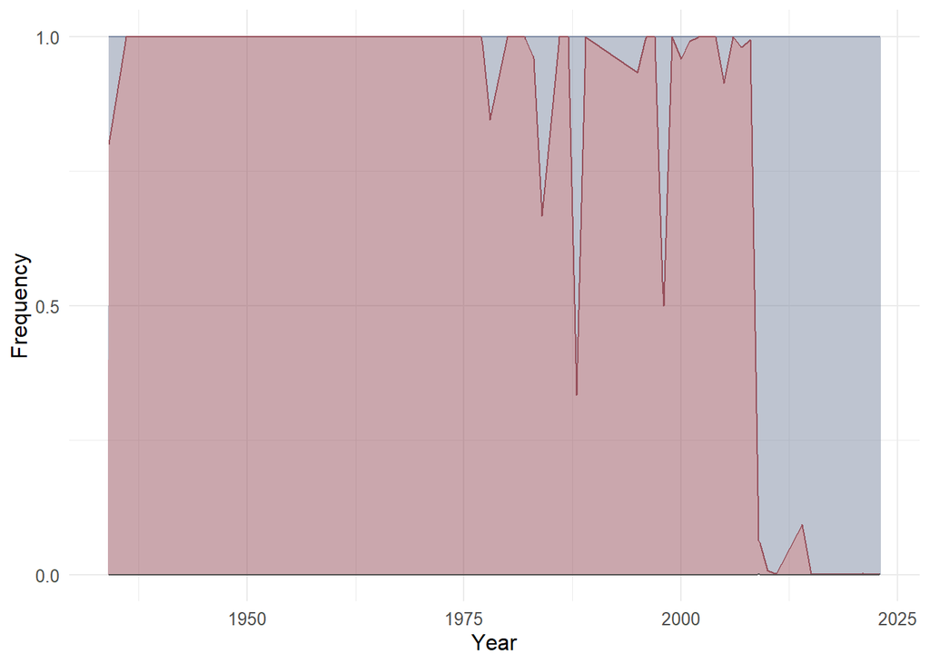

```r
# "-" in site 691 is not caused by deletion but by incomplete sequences, therefore, "-" should not be counted as a level or calculated in frequency
# I removed column "-" in the matrix "freq691"
freq691_complete <- freq691[,colnames(freq691)!="-"]

freq691_long <- as.data.frame(freq691_complete) %>%
  group_by(group) %>%
  mutate(perc = Freq/sum(Freq))

ggplot(freq691_long, aes(x = as.numeric(as.character(group)),
                         y = perc, fill = X691, color = X691)) +
    geom_area(alpha = 0.5) +
    scale_fill_manual(values = palette_691) +
    scale_color_manual(values = palette_691) +
    scale_y_continuous(breaks = c(0, 0.5, 1.0)) +
    theme_minimal() +
    labs(x = "Year", y = "Frequency" ) +
    theme(text = element_text(size = 12), legend.position="none")
```

Although *K (Lys)* is the wildtype in WSN33, *R (Arg)* seemed to be the more dominant amino acid before 2009, which means this mutation is likely to be a real beneficial one and actually happened in nature. At 2009, there was an evolutionary sweep that made *K* the dominant amino acid till now.

### Site 679

```r
# beneficial mutations at that site
benemut4[which(benemut4$site == 679), ]$mt
```

```
## [1] "N"
```

```r
# naturally occurred mutations at that site
unique(nat_aa$X679)
```

```
## [1] "Q" "X" "-" "H" "E" "A" "S" "D" "P"
```

```r
# compare
benemut4[which(benemut4$site == 679), ]$mt %in% unique(nat_aa$X679)
```

```
## [1] FALSE
```

### Site 510

```r
# beneficial mutations at that site
benemut4[which(benemut4$site == 510), ]$mt
```

```
## [1] "A" "G"
```

```r
# naturally occurred mutations at that site
unique(nat_aa$X510)
```

```
## [1] "P" "X" "S" "-" "V" "L"
```

```r
# compare
benemut4[which(benemut4$site == 510), ]$mt %in% unique(nat_aa$X510)
```

```
## [1] FALSE FALSE
```

### Site 151

```r
# beneficial mutations at that site
benemut4[which(benemut4$site == 151), ]$mt
```

```
## [1] "L"
```

```r
# naturally occurred mutations at that site
unique(nat_aa$X151)
```

```
## [1] "R" "-" "X" "G" "K" "I"
```

```r
# compare
benemut4[which(benemut4$site == 151), ]$mt %in% unique(nat_aa$X151)
```

```
## [1] FALSE
```

### Site 164

```r
# beneficial mutations at that site
benemut4[which(benemut4$site == 164), ]$mt
```

```
## [1] "L"
```

```r
# naturally occurred mutations at that site
unique(nat_aa$X164)
```

```
## [1] "I" "-" "L" "X" "V"
```

```r
# compare
benemut4[which(benemut4$site == 164), ]$mt %in% unique(nat_aa$X164)
```

```
## [1] TRUE
```

```r
# if the beneficial mutation has appeared, when?
nat_aa[which(nat_aa$X164 == "L"), ] %>%
  select(colnames(nat_metadata))
```

```
##          Isolate_Id         Isolate_Name Passage_History
## 385   EPI_ISL_33875 A/New York/3992/2009            <NA>
## 7477 EPI_ISL_210306    A/Montana/04/2016        Original
##       Host Collection_Date group
## 385  Human      2009-06-10  2009
## 7477 Human      2016-01-08  2016
```

```r
# how frequently did the mutation happen?
filter(nat_aa, group %in% c(2009,2016)) %>%
  group_by(group) %>%
  select(X164) %>%
  table()
```

```
##       X164
## group     -    I    L    V    X
##   2009    2 4771    1    3    2
##   2016    0 3591    1    1    1
```

### Site 351

```r
# beneficial mutations at that site
benemut4[which(benemut4$site == 351), ]$mt
```

```
## [1] "R"
```

```r
# naturally occurred mutations at that site
unique(nat_aa$X351)
```

```
## [1] "L" "-" "X" "I" "M" "Y" "*"
```

```r
# compare
benemut4[which(benemut4$site == 351), ]$mt %in% unique(nat_aa$X351)
```

```
## [1] FALSE
```

### Site 105

```r
# beneficial mutations at that site
benemut4[which(benemut4$site == 105), ]$mt
```

```
## [1] "R"
```

```r
# naturally occurred mutations at that site
unique(nat_aa$X105)
```

```
## [1] "N" "-" "S" "T" "X" "D" "A" "H" "I"
```

```r
# compare
benemut4[which(benemut4$site == 105), ]$mt %in% unique(nat_aa$X105)
```

```
## [1] FALSE
```

The wildtype at site 105 seem to be *N (Asn)* rather than *T (Thr)* (which was the case for WSN33), although T was found in both early (1932, 1933) and late (2019, 2020) years. $Min_{T \rightarrow R} = 1$, $Min_{N \rightarrow R} = 2$, which might be a reason why mutation R (Arg) was not observed.

### Site 323

```r
# beneficial mutations at that site
benemut4[which(benemut4$site == 323), ]$mt
```

```
## [1] "M"
```

```r
# naturally occurred mutations at that site
unique(nat_aa$X323)
```

```
## [1] "T" "-" "K" "X" "S" "E" "A" "M"
```

```r
# compare
benemut4[which(benemut4$site == 323), ]$mt %in% unique(nat_aa$X323)
```

```
## [1] TRUE
```

```r
# if the beneficial mutation has appeared, when?
nat_aa[which(nat_aa$X323 == "M"), ] %>%
  select(colnames(nat_metadata))
```

```
##           Isolate_Id                Isolate_Name
## 27760 EPI_ISL_717719 A/Netherlands/10370-1a/2020
## 27761 EPI_ISL_717720 A/Netherlands/10370-1b/2020
## 27762 EPI_ISL_717721  A/Netherlands/10370-1/2020
## 27763 EPI_ISL_717722  A/Netherlands/10370-2/2020
##       Passage_History  Host Collection_Date group
## 27760        Original Human      2020-09-09  2020
## 27761        Original Human      2020-09-10  2020
## 27762        Original Human      2020-09-20  2020
## 27763        Original Human      2020-09-24  2020
```

```r
# how frequently did the mutation happen?
filter(nat_aa, group %in% c(2020)) %>%
  group_by(group) %>%
  select(X323) %>%
  table()
```

```
##       X323
## group     A    M    T    X
##   2020    1    4 3461    1
```

The mutation happened recently and rose to 0.1%.

### Site 701

```r
# beneficial mutations at that site
benemut4[which(benemut4$site == 701), ]$mt
```

```
## [1] "L"
```

```r
# naturally occurred mutations at that site
unique(nat_aa$X701)
```

```
## [1] "P" "-" "S" "H" "*" "X" "N" "L"
```

```r
# compare
benemut4[which(benemut4$site == 701), ]$mt %in% unique(nat_aa$X701)
```

```
## [1] TRUE
```

```r
# if the beneficial mutation has appeared, when?
nat_aa[which(nat_aa$X701 == "L"), ] %>%
  select(colnames(nat_metadata))
```

```
##             Isolate_Id              Isolate_Name
## 36051 EPI_ISL_16834452 A/Antananarivo/07513/2022
##       Passage_History  Host Collection_Date group
## 36051              cs Human      2022-12-13  2022
```

```r
# how frequently did the mutation happen?
filter(nat_aa, group %in% c(2022)) %>%
  group_by(group) %>%
  select(X701) %>%
  table()
```

```
##       X701
## group     -    L    P    X
##   2022   14    1 5776    2
```

### Site 261

```r
# beneficial mutations at that site
benemut4[which(benemut4$site == 261), ]$mt
```

```
## [1] "F"
```

```r
# naturally occurred mutations at that site
unique(nat_aa$X261)
```

```
##  [1] "S" "-" "X" "N" "R" "G" "T" "I" "Q" "C"
```

```r
# compare
benemut4[which(benemut4$site == 261), ]$mt %in% unique(nat_aa$X261)
```

```
## [1] FALSE
```

### Site 317

```r
# beneficial mutations at that site
benemut4[which(benemut4$site == 317), ]$mt
```

```
## [1] "V"
```

```r
# naturally occurred mutations at that site
unique(nat_aa$X317)
```

```
## [1] "M" "V" "-" "X" "I" "T" "L"
```

```r
# compare
benemut4[which(benemut4$site == 317), ]$mt %in% unique(nat_aa$X317)
```

```
## [1] TRUE
```

```r
# if the beneficial mutation has appeared, when?
nat_aa[which(nat_aa$X317 == "V"), ] %>%
  select(colnames(nat_metadata)) -> sp
unique(sp$group)
```

```
##  [1] "2009" "2011" "2012" "2013" "2014" "2018" "2019" "2020"
##  [9] "2022" "2023"
```

```r
# how frequently did the mutation happen?
filter(nat_aa, group %in% unique(sp$group)) %>%
  group_by(group) %>%
  select(X317) %>%
  table()
```

```
##       X317
## group     -    I    L    M    T    V    X
##   2009    1    8    0 4758    0    7    5
##   2011    1    0    0  694    0    2    0
##   2012    2    2    0  229    0    1    4
##   2013    0    0    0  429    0    1    4
##   2014    0    0    0  542    0    3    1
##   2018   24    4    0 4658    2    2    7
##   2019   16    6    1 6723    3    5    3
##   2020    0    1    0 3459    1    2    4
##   2022   19   11    0 5704    0    2   57
##   2023   41    1    0 2870    0    2  104
```

The mutation seemed to happen after 2009, and in some years rose to > 0.1%.

### Site 646

```r
# beneficial mutations at that site
benemut4[which(benemut4$site == 646), ]$mt
```

```
## [1] "A"
```

```r
# naturally occurred mutations at that site
unique(nat_aa$X646)
```

```
## [1] "M" "-" "I" "L" "T" "V" "X" "R" "K"
```

```r
# compare
benemut4[which(benemut4$site == 646), ]$mt %in% unique(nat_aa$X646)
```

```
## [1] FALSE
```

### Site 674

```r
# beneficial mutations at that site
benemut4[which(benemut4$site == 674), ]$mt
```

```
## [1] "L"
```

```r
# naturally occurred mutations at that site
unique(nat_aa$X674)
```

```
## [1] "I" "X" "V" "-" "F" "E" "L"
```

```r
# compare
benemut4[which(benemut4$site == 674), ]$mt %in% unique(nat_aa$X674)
```

```
## [1] TRUE
```

```r
# if the beneficial mutation has appeared, when?
nat_aa[which(nat_aa$X674 == "L"), ] %>%
  select(colnames(nat_metadata))
```

```
##             Isolate_Id          Isolate_Name
## 36746 EPI_ISL_17508150 A/Egypt/N228349C/2022
##       Passage_History  Host Collection_Date group
## 36746            <NA> Human      2022-07-19  2022
```

```r
# how frequently did the mutation happen?
filter(nat_aa, group %in% c(2022)) %>%
  group_by(group) %>%
  select(X674) %>%
  table()
```

```
##       X674
## group     -    I    L    X
##   2022   12 5778    1    2
```

### Site 578

```r
# beneficial mutations at that site
benemut4[which(benemut4$site == 578), ]$mt
```

```
## [1] "T"
```

```r
# naturally occurred mutations at that site
unique(nat_aa$X578)
```

```
##  [1] "K" "X" "R" "-" "S" "E" "N" "Q" "M" "T" "I"
```

```r
# compare
benemut4[which(benemut4$site == 578), ]$mt %in% unique(nat_aa$X578)
```

```
## [1] TRUE
```

```r
# if the beneficial mutation has appeared, when?
nat_aa[which(nat_aa$X578 == "T"), ] %>%
  select(colnames(nat_metadata))
```

```
##             Isolate_Id         Isolate_Name Passage_History
## 33379 EPI_ISL_16763992 A/New Mexico/53/2022        Original
##        Host Collection_Date group
## 33379 Human      2022-12-01  2022
```

```r
# how frequently did the mutation happen?
filter(nat_aa, group %in% c(2022)) %>%
  group_by(group) %>%
  select(X578) %>%
  table()
```

```
##       X578
## group     -    K    M    R    T    X
##   2022   12 5776    1    2    1    1
```

### Site 653

```r
# beneficial mutations at that site
benemut4[which(benemut4$site == 653), ]$mt
```

```
## [1] "R"
```

```r
# naturally occurred mutations at that site
unique(nat_aa$X653)
```

```
## [1] "K" "R" "-" "N" "E" "X" "Q" "C" "M"
```

```r
# compare
benemut4[which(benemut4$site == 653), ]$mt %in% unique(nat_aa$X653)
```

```
## [1] TRUE
```

```r
# if the beneficial mutation has appeared, when?
nat_aa[which(nat_aa$X653 == "R"), ] %>%
  select(colnames(nat_metadata)) -> sp
unique(sp$group)
```

```
## [1] "2009" "2016" "2018" "2011" "2019" "2020" "2022" "2023"
## [9] "2006"
```

```r
# how frequently did the mutation happen?
filter(nat_aa, group %in% unique(sp$group)) %>%
  group_by(group) %>%
  select(X653) %>%
  table()
```

```
##       X653
## group     -    C    E    K    M    N    Q    R    X
##   2006    1    0    0  103    0    0    0    1    0
##   2009    2    0    2 4772    0    1    0    2    0
##   2011    3    0    0  693    0    0    0    1    0
##   2016    0    0    0 3593    0    0    0    1    0
##   2018    7    0    0 4689    0    0    0    1    0
##   2019    7    0    0 6748    0    0    0    2    0
##   2020    0    0    0 3465    0    0    0    2    0
##   2022   12    0    0 5771    1    0    2    7    0
##   2023    3    1    0 3004    0    0    0    1    9
```

The mutation happened many times between 2006 and 2023, sometimes rose above 0.1%.

### Site 637

```r
# beneficial mutations at that site
benemut4[which(benemut4$site == 637), ]$mt
```

```
## [1] "V"
```

```r
# naturally occurred mutations at that site
unique(nat_aa$X637)
```

```
## [1] "I" "V" "T" "X" "-" "F" "G" "N"
```

```r
# compare
benemut4[which(benemut4$site == 637), ]$mt %in% unique(nat_aa$X637)
```

```
## [1] TRUE
```

```r
# if the beneficial mutation has appeared, when?
nat_aa[which(nat_aa$X637 == "V"), ] %>%
  select(colnames(nat_metadata)) -> sp
unique(sp$group)
```

```
##  [1] "2009" "2010" "2013" "2015" "2016" "2017" "2012" "2018"
##  [9] "2011" "2019" "2021" "2022" "2023" "2007"
```

```r
# how frequently did the mutation happen?
filter(nat_aa, group %in% unique(sp$group)) %>%
  group_by(group) %>%
  select(X637) %>%
  table()
```

```
##       X637
## group     -    F    G    I    N    T    V    X
##   2007    0    0    0  462    1    0    1    0
##   2009    2    1    0 4736    0    4   35    1
##   2010    2    0    0  920    0    0    4    0
##   2011    3    0    0  693    0    0    1    0
##   2012    3    0    0  233    0    0    1    1
##   2013    1    0    0  431    0    0    2    0
##   2015    0    0    0 1466    0    0    2    0
##   2016    0    0    0 3592    0    0    1    1
##   2017    0    1    0 1941    0    0   13    0
##   2018    7    0    0 4676    0    0   14    0
##   2019    6    1    1 6741    0    2    6    0
##   2021    0    0    0  596    0    0    1    0
##   2022   13    1    0 5758    0    1   20    0
##   2023    3    0    0 3009    0    0    2    4
```

This is a mutation that happened after 2007. It almost happened every year, and frequently rises above 0.1%.

### Site 654

```r
# beneficial mutations at that site
benemut4[which(benemut4$site == 654), ]$mt
```

```
## [1] "D"
```

```r
# naturally occurred mutations at that site
unique(nat_aa$X654)
```

```
##  [1] "S" "N" "X" "-" "I" "T" "G" "H" "R" "K" "C" "A"
```

```r
# compare
benemut4[which(benemut4$site == 654), ]$mt %in% unique(nat_aa$X654)
```

```
## [1] FALSE
```

The wildtype at site 654 was *N (Asn)* before 2009 and became *S (Ser)* after 2009. In WSN33 it was N as well. $Min_{N \rightarrow D} = 1$, $Min_{S \rightarrow D} = 2$. It became more difficult for the mutation to appear after 2009.

## Minimum nucleotide changes in codon vs. natural occurrance

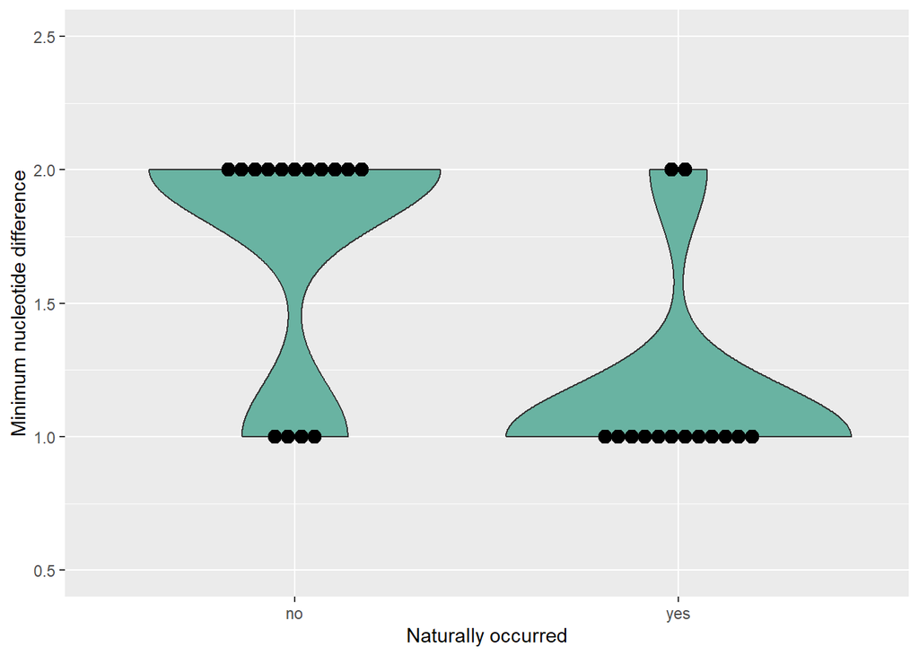

```r
benemut4 <- benemut4 %>%
  mutate(real.MinCodonDiff = ifelse(site %in% c(105, 654), 2, as.numeric(MinCodonDiff))) %>%
  mutate(appeared = case_when(mutation %in% c("Leu108Arg", "Lys577Gln", "Val255Ala", "Met744Ala", "Gln116Val", "Lys691Arg", "Ile164Leu", "Thr323Met", "Pro701Leu", "Met317Val", "Ile674Leu", "Lys578Thr", "Lys653Arg", "Ile637Val") ~ "yes",
                              mutation %in% c("Leu108Tyr", "Pro647Asn", "Val255Ser", "Val255Thr", "Gln116Met", "Gln116Thr", "Gln679Asn", "Pro510Ala", "Pro510Gly", "Arg151Leu", "Leu351Arg", "Thr105Arg", "Ser261Phe", "Met646Ala", "Asn654Asp") ~ "no",
                              T ~ "error"))

ggplot(benemut4, aes(x=appeared, y=real.MinCodonDiff)) +
  geom_violin(fill="#69b3a2") +
  geom_dotplot(binaxis = "y", stackdir = "center",
               binwidth = 1, dotsize=0.05) +
  xlab("Naturally occurred") +
  ylab("Minimum nucleotide difference")
```

```r
# Kolmogorov–Smirnov test: non-parametric, to test whether two samples follow the same distribution using using CDF.
ks.test(as.numeric(filter(benemut4, appeared == "yes")$MinCodonDiff),
        as.numeric(filter(benemut4, appeared == "no")$MinCodonDiff))$p.value
```

```
## [1] 0.09694924
```